# Estudios de Informática, Multimedia y Telecomunicaciones

# PEC 3: Desing and Implementation

UOC - Alumno: Álvaro Rodríguez Sans

May 2020 - Delivery 23/05/2021

The bibliographic references used for this practice have been: (Baayen 2008; Hothorn and Everitt 2014; Hyndman and Athanasopoulos 2021; Liviano Solas and Pujol Jover, n.d.; Teetor 2011; Vegas Lozano, n.d.).

```r
if(!require(knitr)){
    install.packages('knitr', repos='http://cran.us.r-project.org')
    library(knitr)}
if(!require(latexpdf)){
    install.packages('latexpdf', repos='http://cran.us.r-project.org')
    library(latexpdf)}
if(!require(latex2exp)){
    install.packages('latex2exp', repos='http://cran.us.r-project.org')
    library(latex2exp)}
if(!require(psych)){
    install.packages("psych", repos='http://cran.us.r-project.org')
    library(psych)}
if(!require(DescTools)){
    install.packages("DescTools", repos='http://cran.us.r-project.org')
    library(DescTools)}
if(!require(tidyverse)){
    install.packages("tidyverse", repos='http://cran.us.r-project.org')
    library(tidyverse)}
if(!require(imputeTS)){
    install.packages("imputeTS", repos='http://cran.us.r-project.org')
    library(imputeTS)}
if(!require(VIM)){
    install.packages('VIM', repos='http://cran.us.r-project.org')
    library(VIM)}
if(!require(stats)){
    install.packages("stats", repos='http://cran.us.r-project.org')
    library(stats)}
if(!require(tsbox)){
    install.packages("tsbox", repos='http://cran.us.r-project.org')
    library(tsbox)}
if(!require(fable)){
    install.packages("fable", repos='http://cran.us.r-project.org')
    library(fable)}
if(!require(fpp3)){
    install.packages("fpp3", repos='http://cran.us.r-project.org')
    library(fpp3)}
```

```r
if(!require(corrplot)){
    install.packages('corrplot', repos='http://cran.us.r-project.org')
    library(corrplot)}
if(!require(corrplot)){
    install.packages('corrplot', repos='http://cran.us.r-project.org')
    library(corrplot)}
if(!require(forecast)){
    install.packages('forecast', repos='http://cran.us.r-project.org')
    library(forecast)}
if(!require(keras)){
    install.packages('keras', repos='http://cran.us.r-project.org')
    library(keras)}
if(!require(tensorflow)){
    install.packages('tensorflow', repos='http://cran.us.r-project.org')
    library(tensorflow)}
knitr::opts_chunk$set(echo = TRUE)
```

# 1 Data load

Data is loaded from the sources stated at PEC1 and PEC2 (CNE, INE and Google).

- [CNE-Covid-19](https://cnecovid.isciii.es/covid19/#documentacion-y-datos)
- [INE-Covid-19](https://www.ine.es/jaxiT3/Datos.htm?t=37811#!tabs-grafico)
- [Google-Covid-19](https://www.google.com/covid19/mobility/)

```r
#library(dplyr)
# Source INE
EM3 <- read.csv('EM3-Movimiento de personas por provincias.csv',
                header=TRUE,
                sep = ";",
                stringsAsFactors = FALSE)

# Source Google
Google <- read.csv('Google-2020_ES_Region_Mobility_Report.csv',
                   header=TRUE,
                   sep = ";",
                   stringsAsFactors = FALSE)

# Source CNE
CNE_tecnica <- read.csv('CNE-casos_tecnica_provincia.csv',
                        header=TRUE,
                        sep = ",",
                        stringsAsFactors = FALSE)
CNE_casos <- read.csv('CNE-casos_hosp_uci_def_sexo_edad_provres.csv',
                      header=TRUE,
                      sep = ",",
                      stringsAsFactors = FALSE)
```

# 2 Initial descriptive statistics and visualization

## 2.1 Data types and modifications

We are gonig to check the **type of variable** that corresponds to each of the variables (numerical, factor, etc.) and **missing data / values or other anomalies** in each dataset.

### 2.1.1 EM3 review

We have the movement of people by provinces (we can see 146 rows by province, that correspond to days). In order to facilitate the comparison and have a valid reference on to what extent the mobility of the population should be considered to have varied, the data of a day of a week that can be considered “normal” are taken as a reference. For this study, the “normal” day that has been considered is the one that results from the average of the days 18 (Monday) to 21 (Thursday) of November 2019. It is indicated in the tables as the reference date 18/11/2019.

```r
# Source INE
head(str(EM3,vec.len=2))
```

```
## 'data.frame':    9198 obs. of  3 variables:
##  $ Zonas.de.movilidad: chr  "Almería" "Almería" ...
##  $ Periodo           : chr  "30/12/2020" "27/12/2020" ...
##  $ Total             : chr  "17,17" "11,53" ...
```

```r
summary(EM3)
```

```
##  Zonas.de.movilidad   Periodo             Total
##  Length:9198        Length:9198        Length:9198
##  Class :character   Class :character   Class :character
##  Mode  :character   Mode  :character   Mode  :character
```

```r
table(EM3$Zonas.de.movilidad)
```

```
##
##               Albacete       Alicante/Alacant                Almería
##                    146                    146                    146
##            Araba/Álava               Asturias                  Ávila
##                    146                    146                    146
##                Badajoz         Balears, Illes              Barcelona
##                    146                    146                    146
##                Bizkaia                 Burgos                Cáceres
##                    146                    146                    146
##                  Cádiz              Cantabria     Castellón/Castelló
##                    146                    146                    146
##                  Ceuta            Ciudad Real                Córdoba
##                    146                    146                    146
##              Coruña, A                 Cuenca             Formentera
##                    146                    146                    146
##          Fuerteventura               Gipuzkoa                 Girona
##                    146                    146                    146
##             Gomera, La           Gran Canaria                Granada
##                    146                    146                    146
##            Guadalajara             Hierro, El                 Huelva
##                    146                    146                    146
##                 Huesca                  Ibiza                   Jaén
##                    146                    146                    146
##              Lanzarote                   León                 Lleida
##                    146                    146                    146
##                   Lugo                 Madrid                 Málaga
##                    146                    146                    146
##               Mallorca                Melilla                Menorca
##                    146                    146                    146
##                 Murcia                Navarra                Ourense
##                    146                    146                    146
##               Palencia              Palma, La            Palmas, Las
##                    146                    146                    146
##             Pontevedra              Rioja, La              Salamanca
##                    146                    146                    146
## Santa Cruz de Tenerife                Segovia                Sevilla
##                    146                    146                    146
##                  Soria              Tarragona               Tenerife
##                    146                    146                    146
##                 Teruel                 Toledo      Valencia/València
##                    146                    146                    146
##             Valladolid                 Zamora               Zaragoza
##                    146                    146                    146
```

### 2.1.2 EM3 data transformation

We are going to **transform**:

- “Total” from “character” to “numerical”
- “Periodo” from “character” to “date”

```r
EM3$Total <- sub(",", ".", EM3$Total)
EM3$Total <- as.numeric(EM3$Total)
EM3$Periodo <- as.Date(EM3$Periodo,format="%d/%m/%Y")
head(EM3)
```

```
##   Zonas.de.movilidad    Periodo Total
## 1            Almería 2020-12-30 17.17
## 2            Almería 2020-12-27 11.53
## 3            Almería 2020-12-23 17.81
## 4            Almería 2020-12-20 12.13
## 5            Almería 2020-12-16 18.28
## 6            Almería 2020-12-13 11.97
```

### 2.1.3 EM3 transpose

Due to the nature of this dataset we have to transpose it in order to analyse the missing values and impute them.

```r
if(!require(data.table)){
    install.packages('data.table', repos='http://cran.us.r-project.org')
    library(data.table)}

# Transpose dataframe
EM3_t<-dcast(EM3, Periodo~Zonas.de.movilidad, fill=NA)

# Create dates missing (for time series).
# Note: Acccording INE some dates are not provided.
EM3_t<-EM3_t %>%
  complete(Periodo = seq.Date(min(Periodo), max(Periodo), by="day"))

# Filter the interest period according INE EM3 study
EM3_t<- EM3_t %>%
  filter(Periodo <= "2019-11-18" | Periodo >= "2020-03-16")

EM3_t
```

```
## # A tibble: 291 x 64
##    Periodo    Albacete `Alicante/Alaca~ Almería `Araba/Álava` Asturias Ávila
##    <date>        <dbl>            <dbl>   <dbl>         <dbl>    <dbl> <dbl>
##  1 2019-11-18    25.2             28.1    24.4          31.9     29.9  26.6
##  2 2020-03-16     9.9             14.4    11.0          15.9     13.1   9.44
##  3 2020-03-17    NA               NA      NA            NA       NA    NA
##  4 2020-03-18     9.51            13.4     7.28         14.5     12.0   9.17
##  5 2020-03-19    NA               NA      NA            NA       NA    NA
##  6 2020-03-20     8.75            12.0     6.87         11.9     11.3   8.69
##  7 2020-03-21    NA               NA      NA            NA       NA    NA
##  8 2020-03-22     4.5              6.14    4.19          6.46     5.64  4.53
##  9 2020-03-23    NA               NA      NA            NA       NA    NA
## 10 2020-03-24     9.02            10.9     8.98         13.3     11.2   8.26
## # ... with 281 more rows, and 57 more variables: Badajoz <dbl>, `Balears,
## #   Illes` <dbl>, Barcelona <dbl>, Bizkaia <dbl>, Burgos <dbl>, Cáceres <dbl>,
## #   Cádiz <dbl>, Cantabria <dbl>, `Castellón/Castelló` <dbl>, Ceuta <dbl>,
## #   `Ciudad Real` <dbl>, Córdoba <dbl>, `Coruña, A` <dbl>, Cuenca <dbl>,
## #   Formentera <dbl>, Fuerteventura <dbl>, Gipuzkoa <dbl>, Girona <dbl>,
## #   `Gomera, La` <dbl>, `Gran Canaria` <dbl>, Granada <dbl>, Guadalajara <dbl>,
## #   `Hierro, El` <dbl>, Huelva <dbl>, Huesca <dbl>, Ibiza <dbl>, Jaén <dbl>,
## #   Lanzarote <dbl>, León <dbl>, Lleida <dbl>, Lugo <dbl>, Madrid <dbl>,
## #   Málaga <dbl>, Mallorca <dbl>, Melilla <dbl>, Menorca <dbl>, Murcia <dbl>,
## #   Navarra <dbl>, Ourense <dbl>, Palencia <dbl>, `Palma, La` <dbl>, `Palmas,
## #   Las` <dbl>, Pontevedra <dbl>, `Rioja, La` <dbl>, Salamanca <dbl>, `Santa
## #   Cruz de Tenerife` <dbl>, Segovia <dbl>, Sevilla <dbl>, Soria <dbl>,
## #   Tarragona <dbl>, Tenerife <dbl>, Teruel <dbl>, Toledo <dbl>,
## #   `Valencia/València` <dbl>, Valladolid <dbl>, Zamora <dbl>, Zaragoza <dbl>
```

### 2.1.4 EM3 review missing values & impute

We check the missing values by province (we are close to 150 by province).

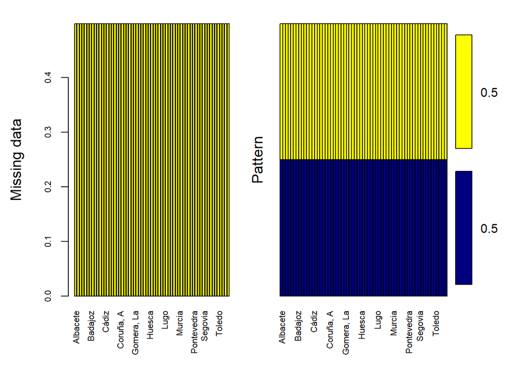

```
##
##  Variables sorted by number of missings:
##                Variable     Count
##                Albacete 0.4982818
##        Alicante/Alacant 0.4982818
##                 Almería 0.4982818
##             Araba/Álava 0.4982818
##                Asturias 0.4982818
##                   Ávila 0.4982818
##                 Badajoz 0.4982818
##          Balears, Illes 0.4982818
##               Barcelona 0.4982818
##                 Bizkaia 0.4982818
##                  Burgos 0.4982818
##                 Cáceres 0.4982818
##                   Cádiz 0.4982818
##               Cantabria 0.4982818
##      Castellón/Castelló 0.4982818
##                   Ceuta 0.4982818
##             Ciudad Real 0.4982818
##                 Córdoba 0.4982818
##               Coruña, A 0.4982818
##                  Cuenca 0.4982818
##              Formentera 0.4982818
##           Fuerteventura 0.4982818
##                Gipuzkoa 0.4982818
##                  Girona 0.4982818
##              Gomera, La 0.4982818
##            Gran Canaria 0.4982818
##                 Granada 0.4982818
##             Guadalajara 0.4982818
##              Hierro, El 0.4982818
##                  Huelva 0.4982818
##                  Huesca 0.4982818
##                   Ibiza 0.4982818
##                    Jaén 0.4982818
##               Lanzarote 0.4982818
##                    León 0.4982818
##                  Lleida 0.4982818
##                    Lugo 0.4982818
```

[output cut: 11 more lines]

```
##              Pontevedra 0.4982818
##               Rioja, La 0.4982818
##               Salamanca 0.4982818
##  Santa Cruz de Tenerife 0.4982818
##                 Segovia 0.4982818
##                 Sevilla 0.4982818
##                   Soria 0.4982818
##               Tarragona 0.4982818
##                Tenerife 0.4982818
##                  Teruel 0.4982818
##                  Toledo 0.4982818
##       Valencia/València 0.4982818
##              Valladolid 0.4982818
##                  Zamora 0.4982818
##                Zaragoza 0.4982818
```

```r
aggr(EM3_t[,-1], col=c('navyblue','yellow'),
     numbers=TRUE, sortVars=TRUE,
     labels=names(EM3_t[,-1]), cex.axis=.7,
     gap=3, ylab=c("Missing data","Pattern"))
```

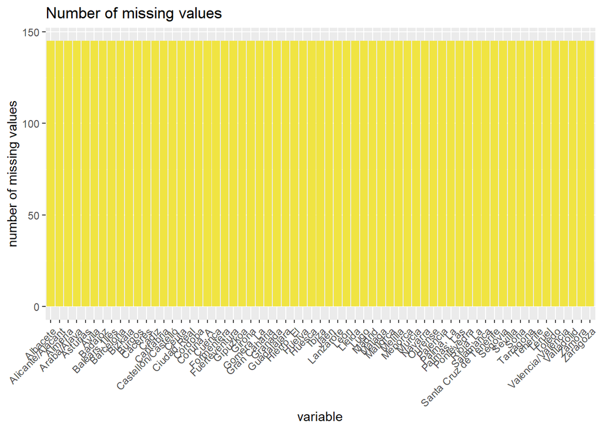

```r
EM3_t %>%
    gather(key = "key", value = "val") %>%
    mutate(is.missing = is.na(val)) %>%
    group_by(key, is.missing) %>%
    summarise(num.missing = n()) %>%
    filter(is.missing==T) %>%
    select(-is.missing) %>%
    arrange(desc(num.missing)) %>%
    ggplot() +
    geom_bar(aes(x=key, y=num.missing), stat = 'identity',fill="#F0E442") +
    labs(x='variable', y="number of missing values",
         title='Number of missing values') +
    theme(axis.text.x = element_text(angle = 45, hjust = 1))
```

We impute the missing values following the principales stated for [imputeTS](https://cran.r-project.org/web/packages/imputeTS/vignettes/imputeTS-Time-Series-Missing-Value-Imputation-in-R.pdf). Thanks to this approach we almost double the amount of data for analysis by province (It was selected “na_seadec” due to it covers seasonality aspects -weekdays/weekends in our case-).

It is needed to transform the dataframe to a time series object.

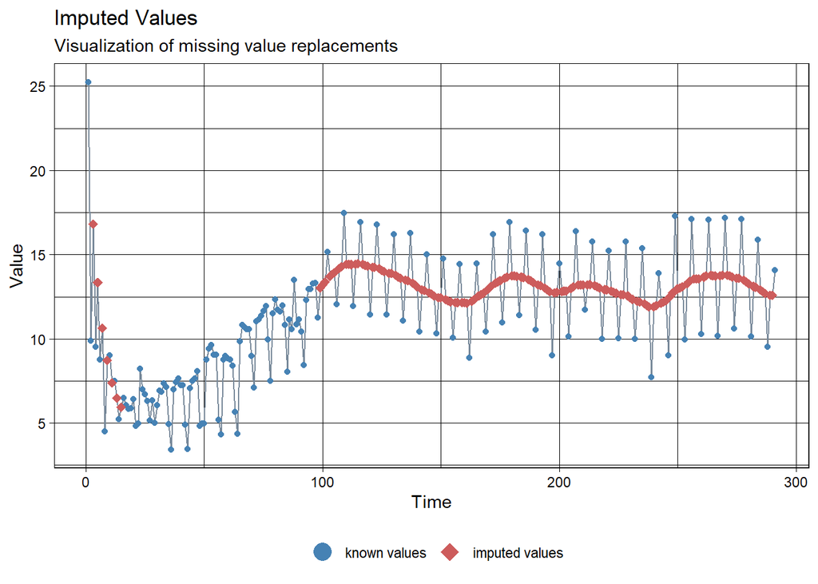

```r
# Used to convert dataframe to ts object
library(xts)
EM3_t_ts<-xts(EM3_t[-1],EM3_t$Periodo)

# Impute the missing values with na_kalman, na_seadec, na_interpolation & na_seasplit
imp <- na_kalman(EM3_t_ts[,1])
ggplot_na_imputations(EM3_t_ts[,1], imp)
```

```r
imp2 <- na_seadec(EM3_t_ts[,1])
ggplot_na_imputations(EM3_t_ts[,1], imp2)
```

[output not shown]

```r
imp3 <- na_seasplit(EM3_t_ts[,1])
ggplot_na_imputations(EM3_t_ts[,1], imp3)
```

[output not shown]

```r
imp4 <- na_interpolation(EM3_t_ts[,1])
ggplot_na_imputations(EM3_t_ts[,1], imp4)
```

[output not shown]

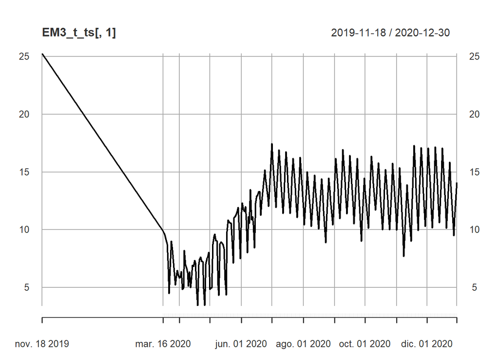

```r
# We select na_seadec for the dataset
EM3_t_ts <- na_seadec(EM3_t_ts)
plot(EM3_t_ts[,1])
```

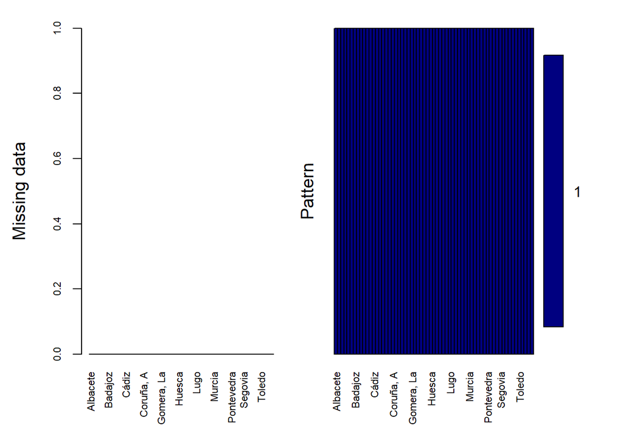

```
##
##  Variables sorted by number of missings:
##                Variable Count
##                Albacete     0
##        Alicante/Alacant     0
##                 Almería     0
##             Araba/Álava     0
##                Asturias     0
##                   Ávila     0
##                 Badajoz     0
##          Balears, Illes     0
##               Barcelona     0
##                 Bizkaia     0
##                  Burgos     0
##                 Cáceres     0
##                   Cádiz     0
##               Cantabria     0
##      Castellón/Castelló     0
##                   Ceuta     0
##             Ciudad Real     0
##                 Córdoba     0
##               Coruña, A     0
##                  Cuenca     0
##              Formentera     0
##           Fuerteventura     0
##                Gipuzkoa     0
##                  Girona     0
##              Gomera, La     0
##            Gran Canaria     0
##                 Granada     0
##             Guadalajara     0
##              Hierro, El     0
##                  Huelva     0
##                  Huesca     0
##                   Ibiza     0
##                    Jaén     0
##               Lanzarote     0
##                    León     0
##                  Lleida     0
##                    Lugo     0
```

[output cut: 11 more lines]

```
##              Pontevedra     0
##               Rioja, La     0
##               Salamanca     0
##  Santa Cruz de Tenerife     0
##                 Segovia     0
##                 Sevilla     0
##                   Soria     0
##               Tarragona     0
##                Tenerife     0
##                  Teruel     0
##                  Toledo     0
##       Valencia/València     0
##              Valladolid     0
##                  Zamora     0
##                Zaragoza     0
```

```r
# We convert the time series object to a dataframe
EM3 <- ts_df(EM3_t_ts)

names(EM3)[names(EM3) == "id"] <- "Zonas.de.movilidad"
names(EM3)[names(EM3) == "time"] <- "Periodo"
names(EM3)[names(EM3) == "value"] <- "Total"

# Transpose dataframe
EM3_t<-dcast(EM3, Periodo~Zonas.de.movilidad, fill=NA)

# We check again missing values (result should be zero)
aggr(EM3_t[,-1], col=c('navyblue','yellow'),
     numbers=TRUE, sortVars=TRUE,
     labels=names(EM3_t[,-1]), cex.axis=.7,
     gap=3, ylab=c("Missing data","Pattern"))
```

```r
EM3_t %>%
    gather(key = "key", value = "val") %>%
    mutate(is.missing = is.na(val)) %>%
    group_by(key, is.missing) %>%
    summarise(num.missing = n()) %>%
    filter(is.missing==T) %>%
    select(-is.missing) %>%
    arrange(desc(num.missing)) %>%
    ggplot() +
    geom_bar(aes(x=key, y=num.missing), stat = 'identity',fill="#F0E442") +
    labs(x='variable', y="number of missing values",
         title='Number of missing values') +
    theme(axis.text.x = element_text(angle = 45, hjust = 1))
```

```r
head(str(EM3,vec.len=2))
```

```
## 'data.frame':    18333 obs. of  3 variables:
##  $ Zonas.de.movilidad: chr  "Albacete" "Albacete" ...
##  $ Periodo           : Date, format: "2019-11-18" "2020-03-16" ...
##  $ Total             : num  25.2 9.9 ...
```

```r
summary(EM3)
```

```
##  Zonas.de.movilidad    Periodo               Total
##  Length:18333       Min.   :2019-11-18   Min.   : 0.83
##  Class :character   1st Qu.:2020-05-26   1st Qu.:10.57
##  Mode  :character   Median :2020-08-07   Median :14.13
##                     Mean   :2020-08-06   Mean   :13.79
##                     3rd Qu.:2020-10-19   3rd Qu.:17.06
##                     Max.   :2020-12-30   Max.   :36.70
```

```r
table(EM3$Zonas.de.movilidad)
```

```
##
##               Albacete       Alicante/Alacant                Almería
##                    291                    291                    291
##            Araba/Álava               Asturias                  Ávila
##                    291                    291                    291
##                Badajoz         Balears, Illes              Barcelona
##                    291                    291                    291
##                Bizkaia                 Burgos                Cáceres
##                    291                    291                    291
##                  Cádiz              Cantabria     Castellón/Castelló
##                    291                    291                    291
##                  Ceuta            Ciudad Real                Córdoba
##                    291                    291                    291
##              Coruña, A                 Cuenca             Formentera
##                    291                    291                    291
##          Fuerteventura               Gipuzkoa                 Girona
##                    291                    291                    291
##             Gomera, La           Gran Canaria                Granada
##                    291                    291                    291
##            Guadalajara             Hierro, El                 Huelva
##                    291                    291                    291
##                 Huesca                  Ibiza                   Jaén
##                    291                    291                    291
##              Lanzarote                   León                 Lleida
##                    291                    291                    291
##                   Lugo                 Madrid                 Málaga
##                    291                    291                    291
##               Mallorca                Melilla                Menorca
##                    291                    291                    291
##                 Murcia                Navarra                Ourense
##                    291                    291                    291
##               Palencia              Palma, La            Palmas, Las
##                    291                    291                    291
##             Pontevedra              Rioja, La              Salamanca
##                    291                    291                    291
## Santa Cruz de Tenerife                Segovia                Sevilla
##                    291                    291                    291
##                  Soria              Tarragona               Tenerife
##                    291                    291                    291
##                 Teruel                 Toledo      Valencia/València
##                    291                    291                    291
##             Valladolid                 Zamora               Zaragoza
##                    291                    291                    291
```

### 2.1.5 Google review

Here we have data from autonomus communities and provinces.

```r
#Source Google
head(str(Google,vec.len=1))
```

```
## 'data.frame':    24242 obs. of  15 variables:
##  $ country_region_code                               : chr  "ES" ...
##  $ country_region                                    : chr  "Spain" ...
##  $ sub_region_1                                      : chr  "" ...
##  $ sub_region_2                                      : chr  "" ...
##  $ metro_area                                        : logi  NA ...
##  $ iso_3166_2_code                                   : chr  "" ...
##  $ census_fips_code                                  : logi  NA ...
##  $ place_id                                          : chr  "ChIJi7xhMnjjQgwR7KNoB5Qs7KY" ...
##  $ date                                              : chr  "15/02/2020" ...
##  $ retail_and_recreation_percent_change_from_baseline: int  2 2 ...
##  $ grocery_and_pharmacy_percent_change_from_baseline : int  -1 3 ...
##  $ parks_percent_change_from_baseline                : int  26 13 ...
##  $ transit_stations_percent_change_from_baseline     : int  8 5 ...
##  $ workplaces_percent_change_from_baseline           : int  0 -1 ...
##  $ residential_percent_change_from_baseline          : int  -2 -2 ...
```

```r
summary(Google)
```

```
##  country_region_code country_region     sub_region_1       sub_region_2
##  Length:24242        Length:24242       Length:24242       Length:24242
##  Class :character    Class :character   Class :character   Class :character
##  Mode  :character    Mode  :character   Mode  :character   Mode  :character
##
##
##
##
##  metro_area     iso_3166_2_code    census_fips_code   place_id
##  Mode:logical   Length:24242       Mode:logical     Length:24242
##  NA's:24242     Class :character   NA's:24242       Class :character
##                 Mode  :character                    Mode  :character
##
##
##
##
##      date           retail_and_recreation_percent_change_from_baseline
##  Length:24242       Min.   :-97.00
##  Class :character   1st Qu.:-53.00
##  Mode  :character   Median :-32.00
##                     Mean   :-36.42
##                     3rd Qu.:-17.00
##                     Max.   : 71.00
##                     NA's   :56
##  grocery_and_pharmacy_percent_change_from_baseline
##  Min.   :-96.000
##  1st Qu.:-18.000
##  Median : -4.000
##  Mean   : -9.973
##  3rd Qu.:  3.000
##  Max.   :194.000
##  NA's   :396
##  parks_percent_change_from_baseline
##  Min.   :-94.0000
##  1st Qu.:-30.0000
##  Median : -5.0000
##  Mean   : -0.0038
##  3rd Qu.: 22.0000
##  Max.   :543.0000
##  NA's   :305
```

[output cut: 9 more lines]

```
##  Min.   :-92.0
##  1st Qu.:-37.0
##  Median :-24.0
##  Mean   :-26.7
##  3rd Qu.:-13.0
##  Max.   : 55.0
##  NA's   :42
##  residential_percent_change_from_baseline
##  Min.   :-10.000
##  1st Qu.:  4.000
##  Median :  7.000
##  Mean   :  9.419
##  3rd Qu.: 13.000
##  Max.   : 48.000
##  NA's   :267
```

```r
table(Google$sub_region_1)
```

```
##
##                               Andalusia              Aragon            Asturias
##                 385                3465                1540                 385
##    Balearic Islands      Basque Country      Canary Islands           Cantabria
##                 385                1540                1155                 385
##   Castile-La Mancha   Castile and LeÃ³n           Catalonia               Ceuta
##                2310                3850                1925                 378
## Community of Madrid         Extremadura             Galicia            La Rioja
##                 385                1155                1925                 385
##             Melilla             Navarre    Region of Murcia Valencian Community
##                 379                 385                 385                1540
```

```r
table(Google$sub_region_2)
```

```
##
##                                     A CoruÃ±a                 Ã\201lava
##                   7687                    385                    385
##                 Ã\201vila               Albacete               Alicante
##                    385                    385                    385
##               AlmerÃa                Badajoz              Barcelona
##                    385                    385                    385
##                 Biscay                 Burgos               CÃ¡ceres
##                    385                    385                    385
##                 CÃ¡diz               CÃ³rdoba             CastellÃ³n
##                    385                    385                    385
##            Ciudad Real                 Cuenca               Gipuzkoa
##                    385                    385                    385
##                 Girona                Granada            Guadalajara
##                    385                    385                    385
##                 Huelva                 Huesca                  JaÃ©n
##                    385                    385                    385
##             Las Palmas                  LeÃ³n                 Lleida
##                    385                    385                    385
##                   Lugo                MÃ¡laga               Palencia
##                    385                    385                    385
##             Pontevedra    Province of Ourense              Salamanca
##                    385                    385                    385
## Santa Cruz de Tenerife                Segovia                Seville
##                    385                    385                    385
##                  Soria              Tarragona                 Teruel
##                    385                    385                    385
##                 Toledo               Valencia             Valladolid
##                    385                    385                    385
##                 Zamora               Zaragoza
##                    385                    385
```

```r
table(Google$iso_3166_2_code)
```

```
##
##        ES-A ES-AB ES-AL ES-AN ES-AR ES-AS ES-AV  ES-B ES-BA ES-BI ES-BU  ES-C
##   385   385   385   385   385   385   385   385   385   385   385   385   385
## ES-CA ES-CB ES-CC ES-CE ES-CL ES-CM ES-CN ES-CO ES-CR ES-CS ES-CT ES-CU ES-EX
##   385   385   385   378   385   385   385   385   385   385   385   385   385
## ES-GA ES-GC ES-GI ES-GR ES-GU  ES-H ES-HU ES-IB  ES-J  ES-L ES-LE ES-LU ES-MA
##   385   385   385   385   385   385   385   385   385   385   385   385   385
## ES-MC ES-MD ES-ML ES-NC ES-OR  ES-P ES-PO ES-PV ES-RI ES-SA ES-SE ES-SG ES-SO
##   385   385   379   385   385   385   385   385   385   385   385   385   385
## ES-SS  ES-T ES-TE ES-TF ES-TO  ES-V ES-VA ES-VC ES-VI  ES-Z ES-ZA
##   385   385   385   385   385   385   385   385   385   385   385
```

### 2.1.6 Google autonomous-communities & provinces

We check data grouped by autonomous communities and provinces.

```r
Google %>% group_by(sub_region_1) %>% tally()
```

```
## # A tibble: 20 x 2
##    sub_region_1              n
##    <chr>                 <int>
##  1 ""                      385
##  2 "Andalusia"            3465
##  3 "Aragon"               1540
##  4 "Asturias"              385
##  5 "Balearic Islands"      385
##  6 "Basque Country"       1540
##  7 "Canary Islands"       1155
##  8 "Cantabria"             385
##  9 "Castile-La Mancha"    2310
## 10 "Castile and LeÃ³n"    3850
## 11 "Catalonia"            1925
## 12 "Ceuta"                 378
## 13 "Community of Madrid"   385
## 14 "Extremadura"          1155
## 15 "Galicia"              1925
## 16 "La Rioja"              385
## 17 "Melilla"               379
## 18 "Navarre"               385
## 19 "Region of Murcia"      385
## 20 "Valencian Community"  1540
```

```r
Google %>% group_by(sub_region_1) %>% count(sub_region_2)
```

```
## # A tibble: 63 x 3
## # Groups:   sub_region_1 [20]
##    sub_region_1 sub_region_2     n
##    <chr>        <chr>        <int>
##  1 ""           ""             385
##  2 "Andalusia"  ""             385
##  3 "Andalusia"  "AlmerÃa"      385
##  4 "Andalusia"  "CÃ¡diz"       385
##  5 "Andalusia"  "CÃ³rdoba"     385
##  6 "Andalusia"  "Granada"      385
##  7 "Andalusia"  "Huelva"       385
##  8 "Andalusia"  "JaÃ©n"        385
##  9 "Andalusia"  "MÃ¡laga"      385
## 10 "Andalusia"  "Seville"      385
## # ... with 53 more rows
```

In Spain there are **autonomous communities (AC)** and **autonomous cities (C)** that are considered as **provinces (Pr)**. This is the case for:

- AC - Asturias, Principality - Pr - Asturias
- AC - Balears, Illes - Pr - Balears, Illes
- AC - Cantabria - Pr - Cantabria
- AC - Madrid, Community - Pr - Madrid
- AC - Murcia, Region - Pr- Murcia
- AC - Navarra, Foral Community - Pr - Navarra
- AC - Rioja, La - Pr - Rioja, La
- C - Ceuta - C/Pr - Ceuta
- C - Melilla - C/Pr - Melilla

In this data set, the empty values in the “sub_region_2” column, for the autonomous communities mentinoed, will be replaced by the value contained in the “sub_region_1” column (A). Also we are going to modify the names of the provinces that have special characters in order to adopt the INE standards (B). See note.

**Note** The following links states the provinces in Spain [INE CCAA](https://www.ine.es/daco/daco42/codmun/cod_ccaa_provincia.htm) and its [ISO codes](https://es.wikipedia.org/wiki/ISO_3166-2:ES) are going to be used as tables of referencence.

```r
# Modidication provinces - A
Google$sub_region_2[Google$sub_region_1=="Balearic Islands"] <- "Balears, Illes"
Google$iso_3166_2_code[Google$sub_region_2=="Balears, Illes"] <- "PM"

Google$sub_region_2[Google$sub_region_1=="Asturias"] <- "Asturias"
Google$iso_3166_2_code[Google$sub_region_2=="Asturias"] <- "O"

Google$sub_region_2[Google$sub_region_1=="Cantabria"] <- "Cantabria"
Google$iso_3166_2_code[Google$sub_region_2=="Cantabria"] <- "S"

Google$sub_region_2[Google$sub_region_1=="Community of Madrid"] <- "Madrid"
Google$iso_3166_2_code[Google$sub_region_2=="Madrid"] <- "M"

Google$sub_region_2[Google$sub_region_1=="Region of Murcia"] <- "Murcia"
Google$iso_3166_2_code[Google$sub_region_2=="Murcia"] <- "MU"

Google$sub_region_2[Google$sub_region_1=="Navarre"] <- "Navarra"
Google$iso_3166_2_code[Google$sub_region_2=="Navarra"] <- "NA"

Google$sub_region_2[Google$sub_region_1=="La Rioja"] <- "Rioja, La"
Google$iso_3166_2_code[Google$sub_region_2=="Rioja, La"] <- "LO"

Google$sub_region_2[Google$sub_region_1=="Ceuta"] <- "Ceuta"
Google$iso_3166_2_code[Google$sub_region_2=="Ceuta"] <- "CE"

Google$sub_region_2[Google$sub_region_1=="Melilla"] <- "Melilla"
Google$iso_3166_2_code[Google$sub_region_2=="Melilla"] <- "ML"

# Modidication provinces - B
Google$sub_region_2[Google$sub_region_2=="A CoruÃ±a"]<-"Coruña, A"
Google$sub_region_2[Google$sub_region_2=="Ã\u0081lava"]<-"Araba/Álava"
Google$sub_region_2[Google$sub_region_2=="Ã\u0081vila"]<-"Ávila"
#Google$sub_region_2[Google$sub_region_2=="Albacete"]<-"Albacete"
Google$sub_region_2[Google$sub_region_2=="Alicante"]<-"Alicante/Alacant"
#Google$sub_region_2[Google$sub_region_2=="AlmerÃa"]<-"Almería"
#Google$sub_region_2[Google$sub_region_2=="Asturias"]<-"Asturias"
#Google$sub_region_2[Google$sub_region_2=="Badajoz"]<-"Badajoz"
#Google$sub_region_2[Google$sub_region_2=="Balears, Illes"]<-"Balears, Illes"
#Google$sub_region_2[Google$sub_region_2=="Barcelona"]<-"Barcelona"
Google$sub_region_2[Google$sub_region_2=="Biscay"]<-"Bizkaia"
#Google$sub_region_2[Google$sub_region_2=="Burgos"]<-"Burgos"
Google$sub_region_2[Google$sub_region_2=="CÃ¡ceres"]<-"Cáceres"
Google$sub_region_2[Google$sub_region_2=="CÃ¡diz"]<-"Cádiz"
Google$sub_region_2[Google$sub_region_2=="CÃ³rdoba"]<-"Córdoba"
#Google$sub_region_2[Google$sub_region_2=="Cantabria"]<-"Cantabria"
Google$sub_region_2[Google$sub_region_2=="CastellÃ³n"]<-"Castellón/Castelló"
#Google$sub_region_2[Google$sub_region_2=="Ceuta"]<-"Ceuta"
#Google$sub_region_2[Google$sub_region_2=="Ciudad Real"]<-"Ciudad Real"
#Google$sub_region_2[Google$sub_region_2=="Cuenca"]<-"Cuenca"
#Google$sub_region_2[Google$sub_region_2=="Gipuzkoa"]<-"Gipuzkoa"
#Google$sub_region_2[Google$sub_region_2=="Girona"]<-"Girona"
#Google$sub_region_2[Google$sub_region_2=="Granada"]<-"Granada"
#Google$sub_region_2[Google$sub_region_2=="Guadalajara"]<-"Guadalajara"
#Google$sub_region_2[Google$sub_region_2=="Huelva"]<-"Huelva"
#Google$sub_region_2[Google$sub_region_2=="Huesca"]<-"Huesca"
Google$sub_region_2[Google$sub_region_2=="JaÃ©n"]<-"Jaén"
Google$sub_region_2[Google$sub_region_2=="Las Palmas"]<-"Palmas, Las"
Google$sub_region_2[Google$sub_region_2=="LeÃ³n"]<-"León"
#Google$sub_region_2[Google$sub_region_2=="Lleida"]<-"Lleida"
#Google$sub_region_2[Google$sub_region_2=="Lugo"]<-"Lugo"
Google$sub_region_2[Google$sub_region_2=="MÃ¡laga"]<-"Málaga"
#Google$sub_region_2[Google$sub_region_2=="Madrid"]<-"Madrid"
#Google$sub_region_2[Google$sub_region_2=="Melilla"]<-"Melilla"
#Google$sub_region_2[Google$sub_region_2=="Murcia"]<-"Murcia"
#Google$sub_region_2[Google$sub_region_2=="Navarra"]<-"Navarra"
#Google$sub_region_2[Google$sub_region_2=="Palencia"]<-"Palencia"
#Google$sub_region_2[Google$sub_region_2=="Pontevedra"]<-"Pontevedra"
Google$sub_region_2[Google$sub_region_2=="Province of Ourense"]<-"Ourense"
#Google$sub_region_2[Google$sub_region_2=="Rioja, La"]<-"Rioja, La"
#Google$sub_region_2[Google$sub_region_2=="Salamanca"]<-"Salamanca"
#Google$sub_region_2[Google$sub_region_2=="Santa Cruz de Tenerife"]<-"Santa Cruz de Tenerife"
#Google$sub_region_2[Google$sub_region_2=="Segovia"]<-"Segovia"
Google$sub_region_2[Google$sub_region_2=="Seville"]<-"Sevilla"
#Google$sub_region_2[Google$sub_region_2=="Soria"]<-"Soria"
#Google$sub_region_2[Google$sub_region_2=="Tarragona"]<-"Tarragona"
#Google$sub_region_2[Google$sub_region_2=="Teruel"]<-"Teruel"
#Google$sub_region_2[Google$sub_region_2=="Toledo"]<-"Toledo"
Google$sub_region_2[Google$sub_region_2=="Valencia"]<-"Valencia/València"
#Google$sub_region_2[Google$sub_region_2=="Valladolid"]<-"Valladolid"
#Google$sub_region_2[Google$sub_region_2=="Zamora"]<-"Zamora"
#Google$sub_region_2[Google$sub_region_2=="Zaragoza"]<-"Zaragoza"
Google$sub_region_2 <- with(Google, ifelse(grepl("^Almer", sub_region_2),
                                                  "Almería", sub_region_2))

table(Google$sub_region_2)
```

```
##
##                                      Albacete       Alicante/Alacant
##                   4235                    385                    385
##                Almería            Araba/Álava               Asturias
##                    385                    385                    385
##                  Ávila                Badajoz         Balears, Illes
##                    385                    385                    385
##              Barcelona                Bizkaia                 Burgos
##                    385                    385                    385
##                Cáceres                  Cádiz              Cantabria
##                    385                    385                    385
##     Castellón/Castelló                  Ceuta            Ciudad Real
##                    385                    378                    385
##                Córdoba              Coruña, A                 Cuenca
##                    385                    385                    385
##               Gipuzkoa                 Girona                Granada
##                    385                    385                    385
##            Guadalajara                 Huelva                 Huesca
##                    385                    385                    385
##                   Jaén                   León                 Lleida
##                    385                    385                    385
##                   Lugo                 Madrid                 Málaga
##                    385                    385                    385
##                Melilla                 Murcia                Navarra
##                    379                    385                    385
##                Ourense               Palencia            Palmas, Las
##                    385                    385                    385
##             Pontevedra              Rioja, La              Salamanca
##                    385                    385                    385
## Santa Cruz de Tenerife                Segovia                Sevilla
##                    385                    385                    385
##                  Soria              Tarragona                 Teruel
##                    385                    385                    385
##                 Toledo      Valencia/València             Valladolid
##                    385                    385                    385
##                 Zamora               Zaragoza
##                    385                    385
```

```r
table(Google$iso_3166_2_code)
```

```
##
##          CE  ES-A ES-AB ES-AL ES-AN ES-AR ES-AV  ES-B ES-BA ES-BI ES-BU  ES-C
##   385   378   385   385   385   385   385   385   385   385   385   385   385
## ES-CA ES-CC ES-CL ES-CM ES-CN ES-CO ES-CR ES-CS ES-CT ES-CU ES-EX ES-GA ES-GC
##   385   385   385   385   385   385   385   385   385   385   385   385   385
## ES-GI ES-GR ES-GU  ES-H ES-HU  ES-J  ES-L ES-LE ES-LU ES-MA ES-OR  ES-P ES-PO
##   385   385   385   385   385   385   385   385   385   385   385   385   385
## ES-PV ES-SA ES-SE ES-SG ES-SO ES-SS  ES-T ES-TE ES-TF ES-TO  ES-V ES-VA ES-VC
##   385   385   385   385   385   385   385   385   385   385   385   385   385
## ES-VI  ES-Z ES-ZA    LO     M    ML    MU    NA     O    PM     S
##   385   385   385   385   385   379   385   385   385   385   385
```

### 2.1.7 Google data transformation

We are going to **transform / eliminate**:

- A - Rows with “na” / "" in “sub_region_1” and “sub_region_2” columns are eliminated.
- B - Date column is transformed from “character” to “date”.
- C - Some columns are eliminated due to they are not adding value or they contain blanks (country_region_code, country_region, metro_area, census_fips_code, pace_id).
- D - “ES-” is elimianted from “iso_3166_2_code” column.

```r
# Transform / eliminate A
Google <- filter(Google, sub_region_1 != "", sub_region_2 != "" )

# Transform / eliminate B
Google$date <- as.Date(Google$date ,format="%d/%m/%Y")

# Transform / eliminate C
Google<-within(Google, rm(country_region_code,
                  country_region,
                  metro_area,
                  census_fips_code,
                  place_id))

# Transform / eliminate D
Google$iso_3166_2_code <- gsub("ES-", "", Google$iso_3166_2_code)

#Google$retail_and_recreation_percent_change_from_baseline <- as.numeric(Google$retail_and_recreation_percent_change_from_baseline)
#Google$grocery_and_pharmacy_percent_change_from_baseline <- as.numeric(Google$grocery_and_pharmacy_percent_change_from_baseline)
#Google$parks_percent_change_from_baseline <- as.numeric(Google$parks_percent_change_from_baseline)
#Google$transit_stations_percent_change_from_baseline <- as.numeric(Google$transit_stations_percent_change_from_baseline)
#Google$workplaces_percent_change_from_baseline <- as.numeric(Google$workplaces_percent_change_from_baseline)
#Google$residential_percent_change_from_baseline <- as.numeric(Google$residential_percent_change_from_baseline)

head(Google,5)
```

```
##   sub_region_1 sub_region_2 iso_3166_2_code       date
## 1    Andalusia      Almería              AL 2020-02-15
## 2    Andalusia      Almería              AL 2020-02-16
## 3    Andalusia      Almería              AL 2020-02-17
## 4    Andalusia      Almería              AL 2020-02-18
## 5    Andalusia      Almería              AL 2020-02-19
##   retail_and_recreation_percent_change_from_baseline
## 1                                                  5
## 2                                                 -2
## 3                                                  0
## 4                                                 -3
## 5                                                 -1
##   grocery_and_pharmacy_percent_change_from_baseline
## 1                                                -3
## 2                                                 0
```

[output cut: 27 more lines]

```r
table(Google$sub_region_2)
```

```
##
##               Albacete       Alicante/Alacant                Almería
##                    385                    385                    385
##            Araba/Álava               Asturias                  Ávila
##                    385                    385                    385
##                Badajoz         Balears, Illes              Barcelona
##                    385                    385                    385
##                Bizkaia                 Burgos                Cáceres
##                    385                    385                    385
##                  Cádiz              Cantabria     Castellón/Castelló
##                    385                    385                    385
##                  Ceuta            Ciudad Real                Córdoba
##                    378                    385                    385
##              Coruña, A                 Cuenca               Gipuzkoa
##                    385                    385                    385
##                 Girona                Granada            Guadalajara
##                    385                    385                    385
##                 Huelva                 Huesca                   Jaén
##                    385                    385                    385
##                   León                 Lleida                   Lugo
##                    385                    385                    385
##                 Madrid                 Málaga                Melilla
##                    385                    385                    379
##                 Murcia                Navarra                Ourense
##                    385                    385                    385
##               Palencia            Palmas, Las             Pontevedra
##                    385                    385                    385
##              Rioja, La              Salamanca Santa Cruz de Tenerife
##                    385                    385                    385
##                Segovia                Sevilla                  Soria
##                    385                    385                    385
##              Tarragona                 Teruel                 Toledo
##                    385                    385                    385
##      Valencia/València             Valladolid                 Zamora
##                    385                    385                    385
##               Zaragoza
##                    385
```

```r
table(Google$iso_3166_2_code)
```

```
##
##   A  AB  AL  AV   B  BA  BI  BU   C  CA  CC  CE  CO  CR  CS  CU  GC  GI  GR  GU
## 385 385 385 385 385 385 385 385 385 385 385 378 385 385 385 385 385 385 385 385
##   H  HU   J   L  LE  LO  LU   M  MA  ML  MU  NA   O  OR   P  PM  PO   S  SA  SE
## 385 385 385 385 385 385 385 385 385 379 385 385 385 385 385 385 385 385 385 385
##  SG  SO  SS   T  TE  TF  TO   V  VA  VI   Z  ZA
## 385 385 385 385 385 385 385 385 385 385 385 385
```

```r
#unique(Google$sub_region_2)
#unique(EM3$Zonas.de.movilidad)
```

### 2.1.8 Google review missing values & impute

We check missing values.

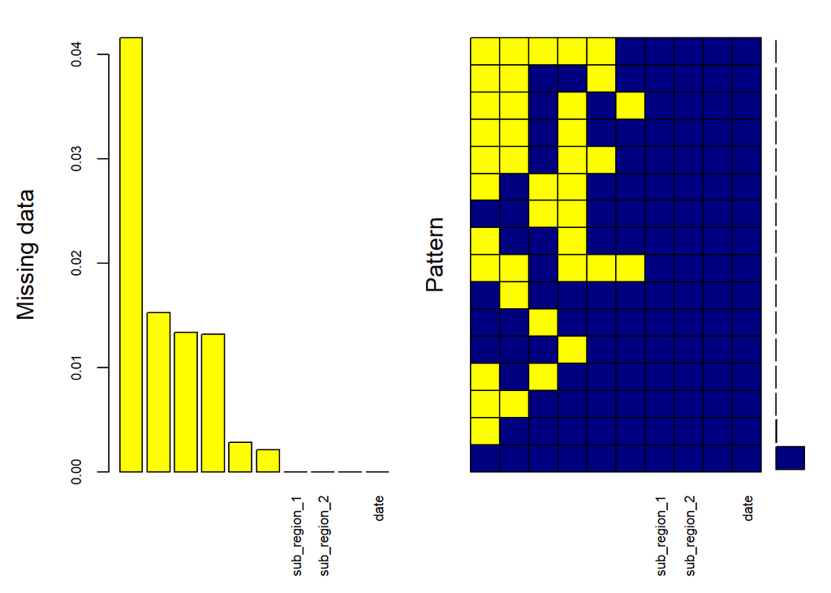

```
##
##  Variables sorted by number of missings:
##                                            Variable       Count
##       transit_stations_percent_change_from_baseline 0.041585445
##                  parks_percent_change_from_baseline 0.015244664
##            residential_percent_change_from_baseline 0.013345329
##   grocery_and_pharmacy_percent_change_from_baseline 0.013195382
##  retail_and_recreation_percent_change_from_baseline 0.002799020
##             workplaces_percent_change_from_baseline 0.002099265
##                                        sub_region_1 0.000000000
##                                        sub_region_2 0.000000000
##                                     iso_3166_2_code 0.000000000
##                                                date 0.000000000
```

```r
aggr(Google, col=c('navyblue','yellow'),
     numbers=TRUE, sortVars=TRUE,
     labels=names(Google), cex.axis=.7,
     gap=3, ylab=c("Missing data","Pattern"))
```

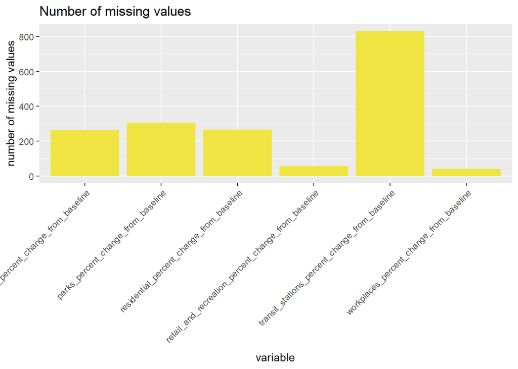

```r
Google %>%
    gather(key = "key", value = "val") %>%
    mutate(is.missing = is.na(val)) %>%
    group_by(key, is.missing) %>%
    summarise(num.missing = n()) %>%
    filter(is.missing==T) %>%
    select(-is.missing) %>%
    arrange(desc(num.missing)) %>%
    ggplot() +
    geom_bar(aes(x=key, y=num.missing), stat = 'identity',fill="#F0E442") +
    labs(x='variable', y="number of missing values",
         title='Number of missing values') +
    theme(axis.text.x = element_text(angle = 45, hjust = 1))
```

We generate 6 new dataframes from the 6 features stated in order to imput missing values using the approach “imputeTS”.

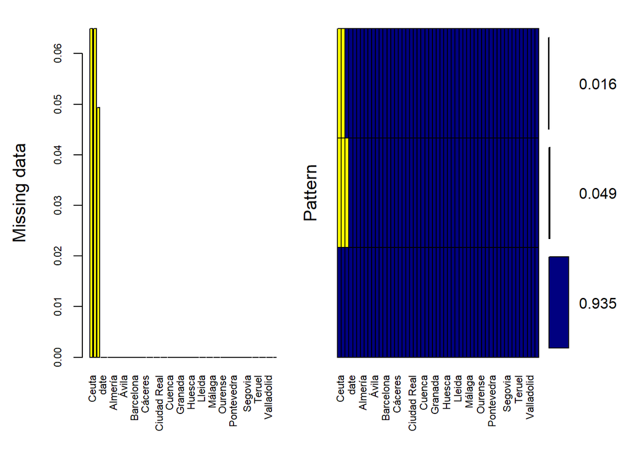

```
##
##  Variables sorted by number of missings:
##                Variable      Count
##                   Ceuta 0.06493506
##                 Melilla 0.06493506
##                   Soria 0.04935065
##                    date 0.00000000
##                Albacete 0.00000000
##        Alicante/Alacant 0.00000000
##                 Almería 0.00000000
##             Araba/Álava 0.00000000
##                Asturias 0.00000000
##                   Ávila 0.00000000
##                 Badajoz 0.00000000
##          Balears, Illes 0.00000000
##               Barcelona 0.00000000
##                 Bizkaia 0.00000000
##                  Burgos 0.00000000
##                 Cáceres 0.00000000
##                   Cádiz 0.00000000
##               Cantabria 0.00000000
##      Castellón/Castelló 0.00000000
##             Ciudad Real 0.00000000
##                 Córdoba 0.00000000
##               Coruña, A 0.00000000
##                  Cuenca 0.00000000
##                Gipuzkoa 0.00000000
##                  Girona 0.00000000
##                 Granada 0.00000000
##             Guadalajara 0.00000000
##                  Huelva 0.00000000
##                  Huesca 0.00000000
##                    Jaén 0.00000000
##                    León 0.00000000
##                  Lleida 0.00000000
##                    Lugo 0.00000000
##                  Madrid 0.00000000
##                  Málaga 0.00000000
##                  Murcia 0.00000000
##                 Navarra 0.00000000
##                 Ourense 0.00000000
##                Palencia 0.00000000
##             Palmas, Las 0.00000000
##              Pontevedra 0.00000000
##               Rioja, La 0.00000000
##               Salamanca 0.00000000
##  Santa Cruz de Tenerife 0.00000000
##                 Segovia 0.00000000
##                 Sevilla 0.00000000
##               Tarragona 0.00000000
##                  Teruel 0.00000000
##                  Toledo 0.00000000
##       Valencia/València 0.00000000
##              Valladolid 0.00000000
##                  Zamora 0.00000000
##                Zaragoza 0.00000000
```

```r
# Transpose dataframe
Google_retail<-Google[c(2,4,5)]
Google_t_retail<-dcast(Google_retail, date~sub_region_2, fill=NA)

# Visualize missing values
aggr(Google_t_retail, col=c('navyblue','yellow'),
     numbers=TRUE, sortVars=TRUE,
     labels=names(Google_t_retail), cex.axis=.7,
     gap=3, ylab=c("Missing data","Pattern"))
```

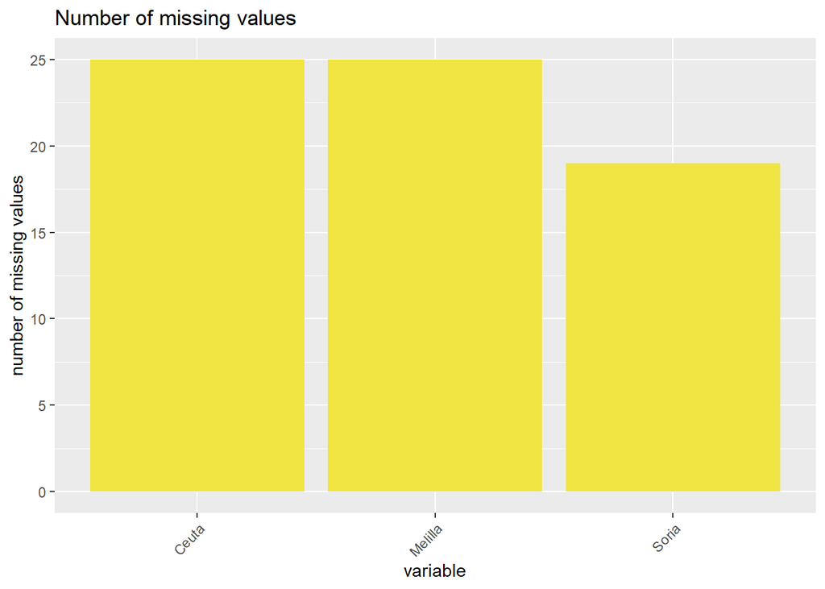

```r
Google_t_retail %>%
    gather(key = "key", value = "val") %>%
    mutate(is.missing = is.na(val)) %>%
    group_by(key, is.missing) %>%
    summarise(num.missing = n()) %>%
    filter(is.missing==T) %>%
    select(-is.missing) %>%
    arrange(desc(num.missing)) %>%
    ggplot() +
    geom_bar(aes(x=key, y=num.missing), stat = 'identity',fill="#F0E442") +
    labs(x='variable', y="number of missing values",
         title='Number of missing values') +
    theme(axis.text.x = element_text(angle = 45, hjust = 1))
```

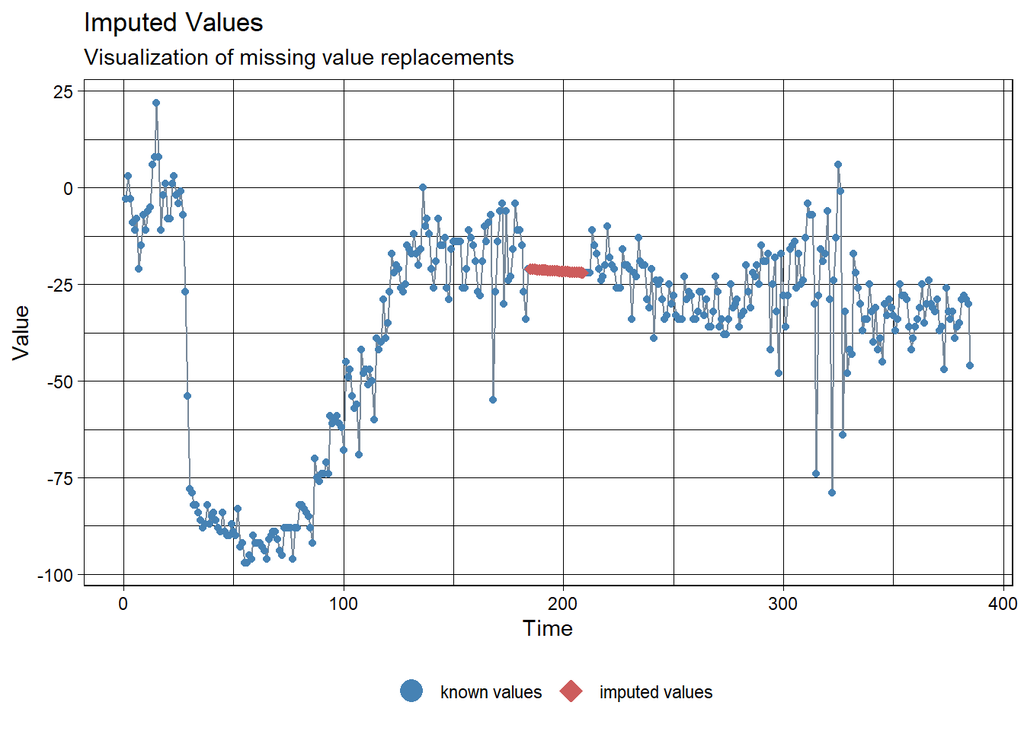

```r
# Convert dataframe to ts object
Google_t_retail_ts<-xts(Google_t_retail[-1],Google_t_retail$date)

# Impute the missing values with na_seadec (i.e Ceuta)
imp5 <- na_seadec(Google_t_retail_ts[,16])
ggplot_na_imputations(Google_t_retail_ts[,16], imp5)
```

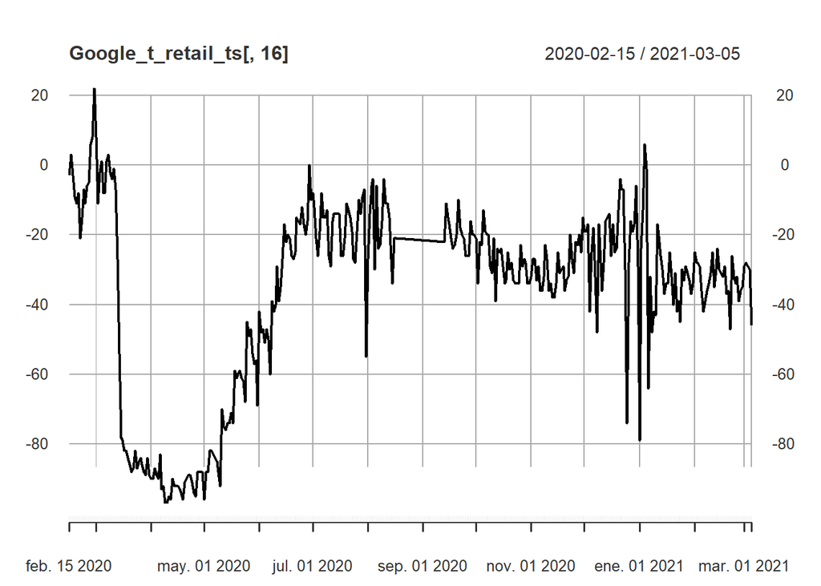

```r
# We select na_seadec for the dataset
Google_t_retail_ts <- na_seadec(Google_t_retail_ts)
plot(Google_t_retail_ts[,16])
```

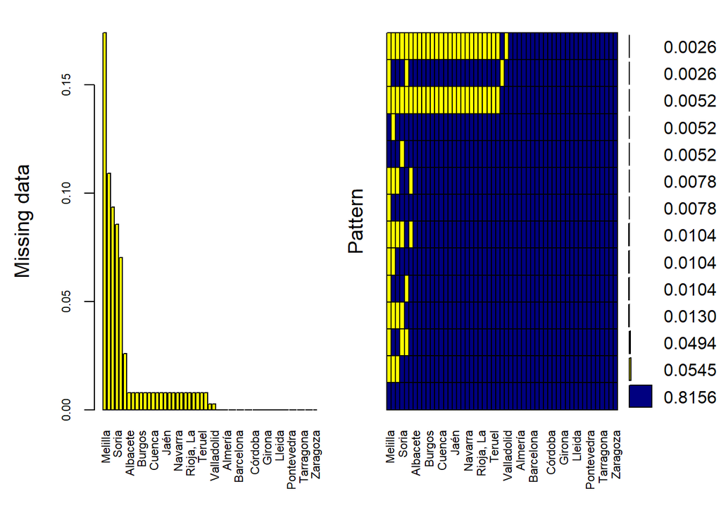

```
##
##  Variables sorted by number of missings:
##                Variable       Count
##                 Melilla 0.174025974
##                Asturias 0.109090909
##                  Murcia 0.093506494
##                   Soria 0.085714286
##                   Ceuta 0.070129870
##               Cantabria 0.025974026
##                Albacete 0.007792208
##             Araba/Álava 0.007792208
##                   Ávila 0.007792208
##                  Burgos 0.007792208
##                 Cáceres 0.007792208
##             Ciudad Real 0.007792208
##                  Cuenca 0.007792208
##             Guadalajara 0.007792208
##                  Huesca 0.007792208
##                    Jaén 0.007792208
##                    León 0.007792208
##                    Lugo 0.007792208
##                 Navarra 0.007792208
##                 Ourense 0.007792208
##                Palencia 0.007792208
##               Rioja, La 0.007792208
##               Salamanca 0.007792208
##                 Segovia 0.007792208
##                  Teruel 0.007792208
##                  Zamora 0.007792208
##                  Madrid 0.002597403
##              Valladolid 0.002597403
##                    date 0.000000000
##        Alicante/Alacant 0.000000000
##                 Almería 0.000000000
##                 Badajoz 0.000000000
##          Balears, Illes 0.000000000
##               Barcelona 0.000000000
##                 Bizkaia 0.000000000
##                   Cádiz 0.000000000
##      Castellón/Castelló 0.000000000
##                 Córdoba 0.000000000
##               Coruña, A 0.000000000
##                Gipuzkoa 0.000000000
##                  Girona 0.000000000
##                 Granada 0.000000000
##                  Huelva 0.000000000
##                  Lleida 0.000000000
##                  Málaga 0.000000000
##             Palmas, Las 0.000000000
##              Pontevedra 0.000000000
##  Santa Cruz de Tenerife 0.000000000
##                 Sevilla 0.000000000
##               Tarragona 0.000000000
##                  Toledo 0.000000000
##       Valencia/València 0.000000000
##                Zaragoza 0.000000000
```

```r
# We convert the time series object to a dataframe
Google_retail <- ts_df(Google_t_retail_ts)

names(Google_retail)[names(Google_retail) == "id"] <- "sub_region_2"
names(Google_retail)[names(Google_retail) == "time"] <- "Date"
names(Google_retail)[names(Google_retail) == "value"] <- "retail_and_recreation_percent_change_from_baseline"

###################################################################
# Transpose dataframe
Google_grocery<-Google[c(2,4,6)]
Google_t_grocery<-dcast(Google_grocery, date~sub_region_2, fill=NA)

# Visualize missing values
aggr(Google_t_grocery, col=c('navyblue','yellow'),
     numbers=TRUE, sortVars=TRUE,
     labels=names(Google_t_grocery), cex.axis=.7,
     gap=3, ylab=c("Missing data","Pattern"))
```

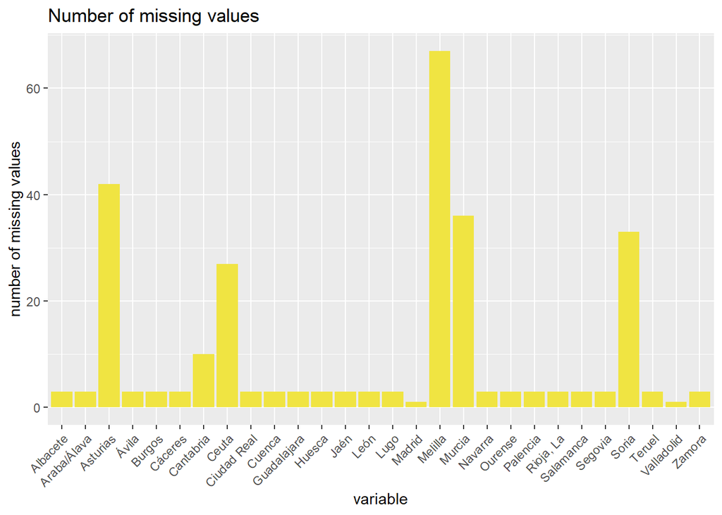

```r
Google_t_grocery %>%
    gather(key = "key", value = "val") %>%
    mutate(is.missing = is.na(val)) %>%
    group_by(key, is.missing) %>%
    summarise(num.missing = n()) %>%
    filter(is.missing==T) %>%
    select(-is.missing) %>%
    arrange(desc(num.missing)) %>%
    ggplot() +
    geom_bar(aes(x=key, y=num.missing), stat = 'identity',fill="#F0E442") +
    labs(x='variable', y="number of missing values",
         title='Number of missing values') +
    theme(axis.text.x = element_text(angle = 45, hjust = 1))
```

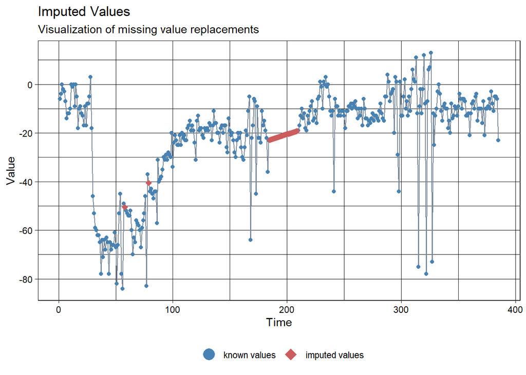

```r
# Convert dataframe to ts object
Google_t_grocery_ts<-xts(Google_t_grocery[-1],Google_t_grocery$date)

# Impute the missing values with na_seadec (i.e Ceuta)
imp6 <- na_seadec(Google_t_grocery_ts[,16])
ggplot_na_imputations(Google_t_grocery_ts[,16], imp6)
```

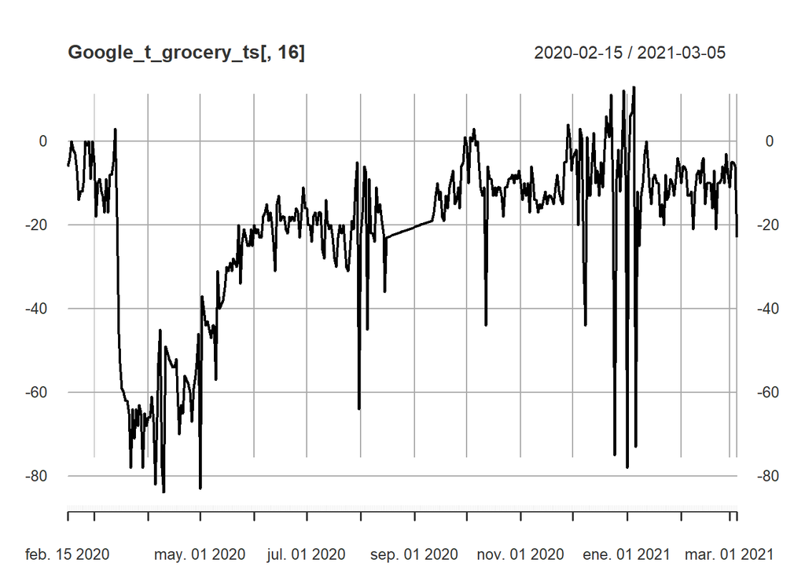

```r
# We select na_seadec for the dataset
Google_t_grocery_ts <- na_seadec(Google_t_grocery_ts)
plot(Google_t_grocery_ts[,16])
```

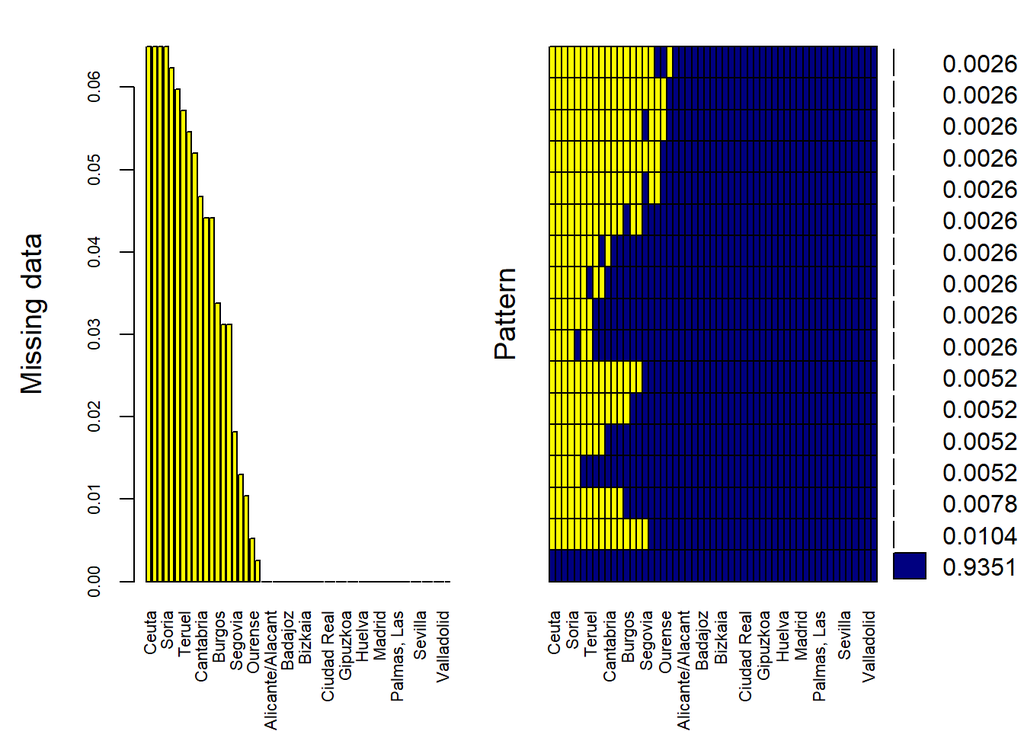

```
##
##  Variables sorted by number of missings:
##                Variable       Count
##                   Ceuta 0.064935065
##                 Melilla 0.064935065
##                Palencia 0.064935065
##                   Soria 0.064935065
##                  Cuenca 0.062337662
##                   Ávila 0.059740260
##                  Teruel 0.057142857
##                  Huesca 0.054545455
##                  Zamora 0.051948052
##               Cantabria 0.046753247
##                  Lleida 0.044155844
##               Rioja, La 0.044155844
##                  Burgos 0.033766234
##             Guadalajara 0.031168831
##                    León 0.031168831
##                 Segovia 0.018181818
##                Albacete 0.012987013
##                 Navarra 0.010389610
##                 Ourense 0.005194805
##                Asturias 0.002597403
##                    date 0.000000000
##        Alicante/Alacant 0.000000000
##                 Almería 0.000000000
##             Araba/Álava 0.000000000
##                 Badajoz 0.000000000
##          Balears, Illes 0.000000000
##               Barcelona 0.000000000
##                 Bizkaia 0.000000000
##                 Cáceres 0.000000000
##                   Cádiz 0.000000000
##      Castellón/Castelló 0.000000000
##             Ciudad Real 0.000000000
##                 Córdoba 0.000000000
##               Coruña, A 0.000000000
##                Gipuzkoa 0.000000000
##                  Girona 0.000000000
##                 Granada 0.000000000
##                  Huelva 0.000000000
##                    Jaén 0.000000000
##                    Lugo 0.000000000
##                  Madrid 0.000000000
##                  Málaga 0.000000000
##                  Murcia 0.000000000
##             Palmas, Las 0.000000000
##              Pontevedra 0.000000000
##               Salamanca 0.000000000
##  Santa Cruz de Tenerife 0.000000000
##                 Sevilla 0.000000000
##               Tarragona 0.000000000
##                  Toledo 0.000000000
##       Valencia/València 0.000000000
##              Valladolid 0.000000000
##                Zaragoza 0.000000000
```

```r
# We convert the time series object to a dataframe
Google_grocery <- ts_df(Google_t_grocery_ts)

names(Google_grocery)[names(Google_grocery) == "id"] <- "sub_region_2"
names(Google_grocery)[names(Google_grocery) == "time"] <- "Date"
names(Google_grocery)[names(Google_grocery) == "value"] <- "grocery_and_pharmacy_percent_change_from_baseline"

###################################################################
# Transpose dataframe
Google_parks<-Google[c(2,4,7)]
Google_t_parks<-dcast(Google_parks, date~sub_region_2, fill=NA)

# Visualize missing values
aggr(Google_t_parks, col=c('navyblue','yellow'),
     numbers=TRUE, sortVars=TRUE,
     labels=names(Google_t_parks), cex.axis=.7,
     gap=3, ylab=c("Missing data","Pattern"))
```

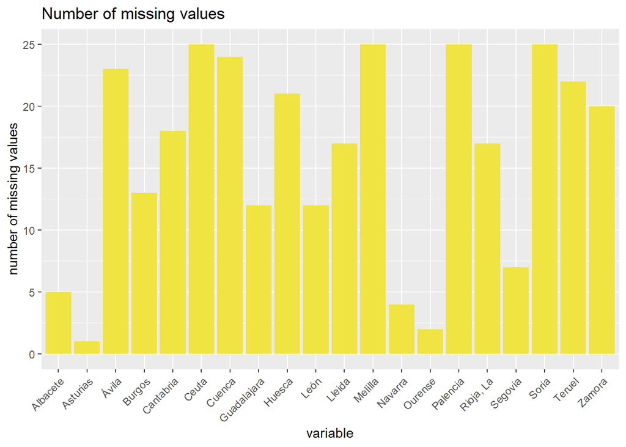

```r
Google_t_parks %>%
    gather(key = "key", value = "val") %>%
    mutate(is.missing = is.na(val)) %>%
    group_by(key, is.missing) %>%
    summarise(num.missing = n()) %>%
    filter(is.missing==T) %>%
    select(-is.missing) %>%
    arrange(desc(num.missing)) %>%
    ggplot() +
    geom_bar(aes(x=key, y=num.missing), stat = 'identity',fill="#F0E442") +
    labs(x='variable', y="number of missing values",
         title='Number of missing values') +
    theme(axis.text.x = element_text(angle = 45, hjust = 1))
```

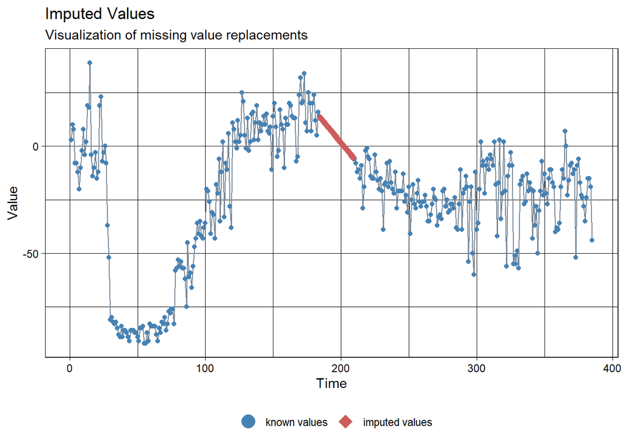

```r
# Convert dataframe to ts object
Google_t_parks_ts<-xts(Google_t_parks[-1],Google_t_parks$date)

# Impute the missing values with na_seadec (i.e Ceuta)
imp7 <- na_seadec(Google_t_parks_ts[,16])
ggplot_na_imputations(Google_t_parks_ts[,16], imp7)
```

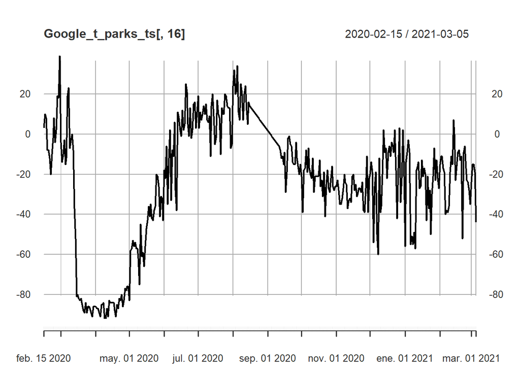

```r
# We select na_seadec for the dataset
Google_t_parks_ts <- na_seadec(Google_t_parks_ts)
plot(Google_t_parks_ts[,16])
```

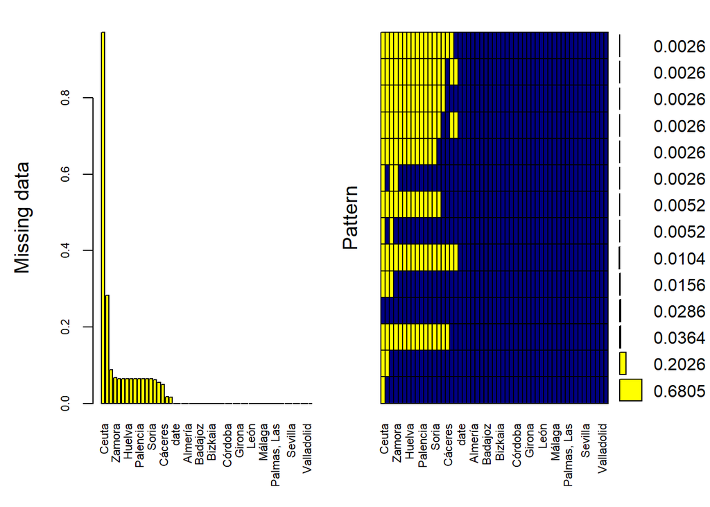

```
##
##  Variables sorted by number of missings:
##                Variable      Count
##                   Ceuta 0.97142857
##                 Melilla 0.28311688
##                  Teruel 0.08831169
##                  Zamora 0.06753247
##                   Ávila 0.06493506
##                  Cuenca 0.06493506
##                  Huelva 0.06493506
##                  Huesca 0.06493506
##                    Lugo 0.06493506
##                Palencia 0.06493506
##               Rioja, La 0.06493506
##                 Segovia 0.06493506
##                   Soria 0.06493506
##                 Ourense 0.06233766
##                  Burgos 0.05454545
##                 Cáceres 0.04935065
##             Ciudad Real 0.01818182
##             Guadalajara 0.01558442
##                    date 0.00000000
##                Albacete 0.00000000
##        Alicante/Alacant 0.00000000
##                 Almería 0.00000000
##             Araba/Álava 0.00000000
##                Asturias 0.00000000
##                 Badajoz 0.00000000
##          Balears, Illes 0.00000000
##               Barcelona 0.00000000
##                 Bizkaia 0.00000000
##                   Cádiz 0.00000000
##               Cantabria 0.00000000
##      Castellón/Castelló 0.00000000
##                 Córdoba 0.00000000
##               Coruña, A 0.00000000
##                Gipuzkoa 0.00000000
##                  Girona 0.00000000
##                 Granada 0.00000000
##                    Jaén 0.00000000
##                    León 0.00000000
##                  Lleida 0.00000000
##                  Madrid 0.00000000
##                  Málaga 0.00000000
##                  Murcia 0.00000000
##                 Navarra 0.00000000
##             Palmas, Las 0.00000000
##              Pontevedra 0.00000000
##               Salamanca 0.00000000
##  Santa Cruz de Tenerife 0.00000000
##                 Sevilla 0.00000000
##               Tarragona 0.00000000
##                  Toledo 0.00000000
##       Valencia/València 0.00000000
##              Valladolid 0.00000000
##                Zaragoza 0.00000000
```

```r
# We convert the time series object to a dataframe
Google_parks <- ts_df(Google_t_parks_ts)

names(Google_parks)[names(Google_parks) == "id"] <- "sub_region_2"
names(Google_parks)[names(Google_parks) == "time"] <- "Date"
names(Google_parks)[names(Google_parks) == "value"] <- "parks_percent_change_from_baseline"

###################################################################
# Transpose dataframe
Google_transit<-Google[c(2,4,8)]
Google_t_transit<-dcast(Google_transit, date~sub_region_2, fill=NA)

# Visualize missing values
aggr(Google_t_transit, col=c('navyblue','yellow'),
     numbers=TRUE, sortVars=TRUE,
     labels=names(Google_t_transit), cex.axis=.7,
     gap=3, ylab=c("Missing data","Pattern"))
```

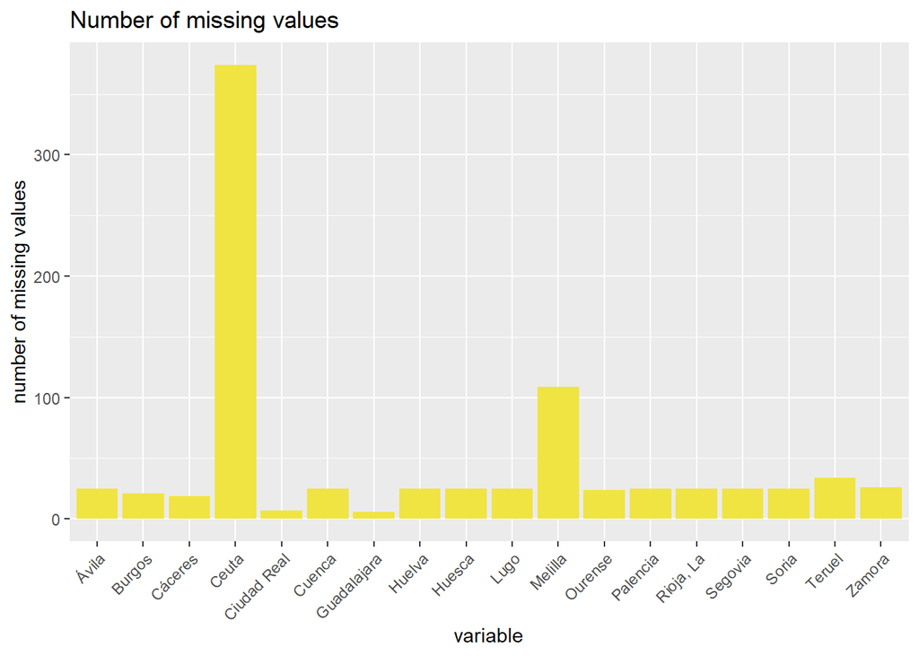

```r
Google_t_transit %>%
    gather(key = "key", value = "val") %>%
    mutate(is.missing = is.na(val)) %>%
    group_by(key, is.missing) %>%
    summarise(num.missing = n()) %>%
    filter(is.missing==T) %>%
    select(-is.missing) %>%
    arrange(desc(num.missing)) %>%
    ggplot() +
    geom_bar(aes(x=key, y=num.missing), stat = 'identity',fill="#F0E442") +
    labs(x='variable', y="number of missing values",
         title='Number of missing values') +
    theme(axis.text.x = element_text(angle = 45, hjust = 1))
```

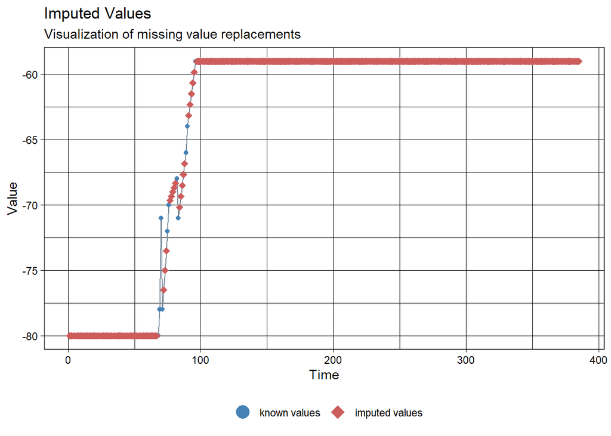

```r
# Convert dataframe to ts object
Google_t_transit_ts<-xts(Google_t_transit[-1],Google_t_transit$date)

# Impute the missing values with na_seadec (i.e Ceuta)
imp8 <- na_seadec(Google_t_transit_ts[,16])
ggplot_na_imputations(Google_t_transit_ts[,16], imp8)
```

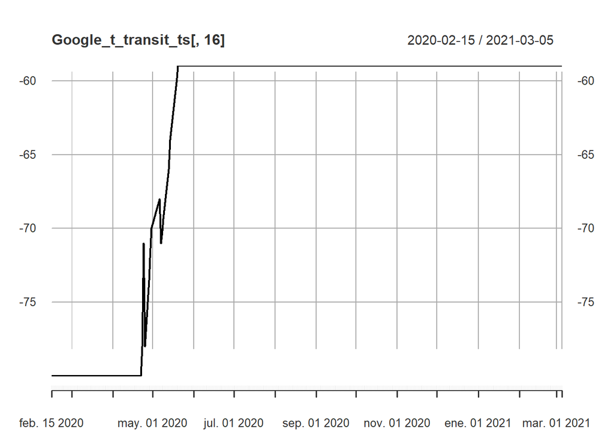

```r
# We select na_seadec for the dataset
Google_t_transit_ts <- na_seadec(Google_t_transit_ts)
plot(Google_t_transit_ts[,16])
```

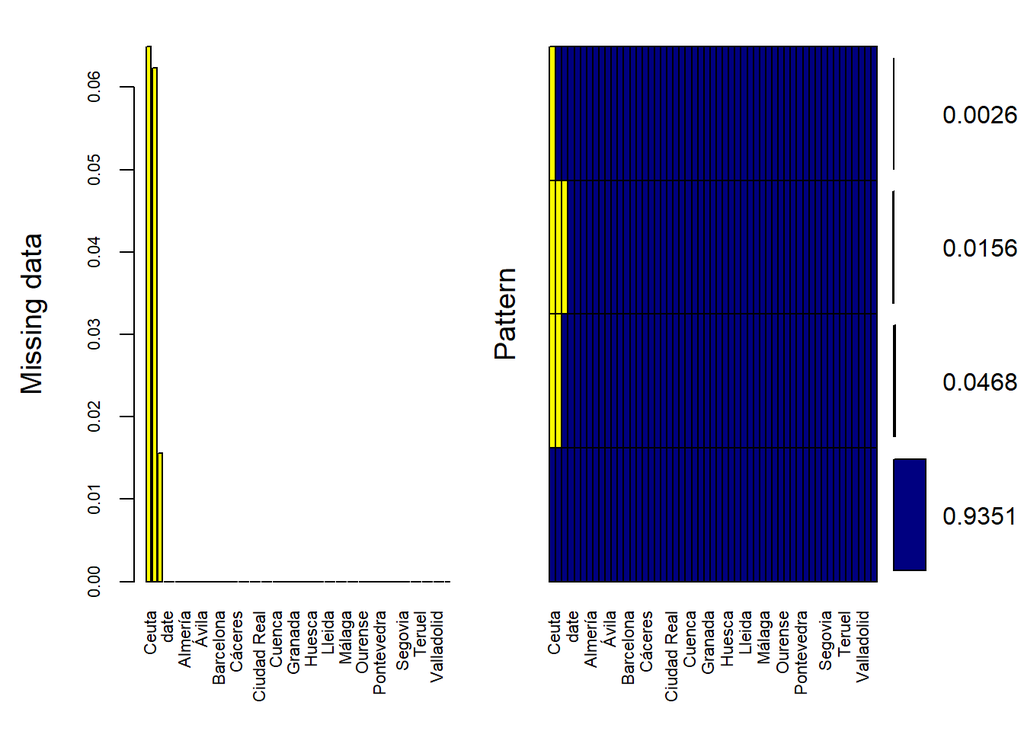

```
##
##  Variables sorted by number of missings:
##                Variable      Count
##                   Ceuta 0.06493506
##                 Melilla 0.06233766
##                   Soria 0.01558442
##                    date 0.00000000
##                Albacete 0.00000000
##        Alicante/Alacant 0.00000000
##                 Almería 0.00000000
##             Araba/Álava 0.00000000
##                Asturias 0.00000000
##                   Ávila 0.00000000
##                 Badajoz 0.00000000
##          Balears, Illes 0.00000000
##               Barcelona 0.00000000
##                 Bizkaia 0.00000000
##                  Burgos 0.00000000
##                 Cáceres 0.00000000
##                   Cádiz 0.00000000
##               Cantabria 0.00000000
##      Castellón/Castelló 0.00000000
##             Ciudad Real 0.00000000
##                 Córdoba 0.00000000
##               Coruña, A 0.00000000
##                  Cuenca 0.00000000
##                Gipuzkoa 0.00000000
##                  Girona 0.00000000
##                 Granada 0.00000000
##             Guadalajara 0.00000000
##                  Huelva 0.00000000
##                  Huesca 0.00000000
##                    Jaén 0.00000000
##                    León 0.00000000
##                  Lleida 0.00000000
##                    Lugo 0.00000000
##                  Madrid 0.00000000
##                  Málaga 0.00000000
##                  Murcia 0.00000000
##                 Navarra 0.00000000
##                 Ourense 0.00000000
##                Palencia 0.00000000
##             Palmas, Las 0.00000000
##              Pontevedra 0.00000000
##               Rioja, La 0.00000000
##               Salamanca 0.00000000
##  Santa Cruz de Tenerife 0.00000000
##                 Segovia 0.00000000
##                 Sevilla 0.00000000
##               Tarragona 0.00000000
##                  Teruel 0.00000000
##                  Toledo 0.00000000
##       Valencia/València 0.00000000
##              Valladolid 0.00000000
##                  Zamora 0.00000000
##                Zaragoza 0.00000000
```

```r
# We convert the time series object to a dataframe
Google_transit <- ts_df(Google_t_transit_ts)

names(Google_transit)[names(Google_transit) == "id"] <- "sub_region_2"
names(Google_transit)[names(Google_transit) == "time"] <- "Date"
names(Google_transit)[names(Google_transit) == "value"] <- "transit_stations_percent_change_from_baseline"

###################################################################
# Transpose dataframe
Google_workplaces<-Google[c(2,4,9)]
Google_t_workplaces<-dcast(Google_workplaces, date~sub_region_2, fill=NA)

# Visualize missing values
aggr(Google_t_workplaces, col=c('navyblue','yellow'),
     numbers=TRUE, sortVars=TRUE,
     labels=names(Google_t_workplaces), cex.axis=.7,
     gap=3, ylab=c("Missing data","Pattern"))
```

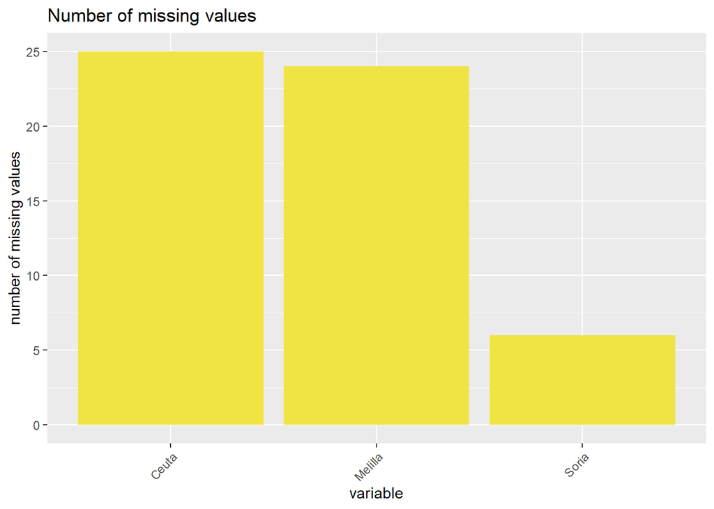

```r
Google_t_workplaces %>%
    gather(key = "key", value = "val") %>%
    mutate(is.missing = is.na(val)) %>%
    group_by(key, is.missing) %>%
    summarise(num.missing = n()) %>%
    filter(is.missing==T) %>%
    select(-is.missing) %>%
    arrange(desc(num.missing)) %>%
    ggplot() +
    geom_bar(aes(x=key, y=num.missing), stat = 'identity',fill="#F0E442") +
    labs(x='variable', y="number of missing values",
         title='Number of missing values') +
    theme(axis.text.x = element_text(angle = 45, hjust = 1))
```

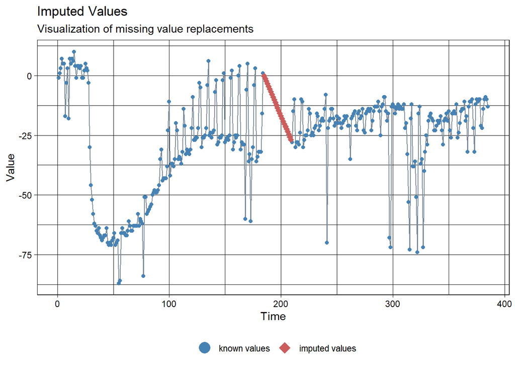

```r
# Convert dataframe to ts object
Google_t_workplaces_ts<-xts(Google_t_workplaces[-1],Google_t_workplaces$date)

# Impute the missing values with na_seadec (i.e Ceuta)
imp9 <- na_seadec(Google_t_workplaces_ts[,16])
ggplot_na_imputations(Google_t_workplaces_ts[,16], imp9)
```

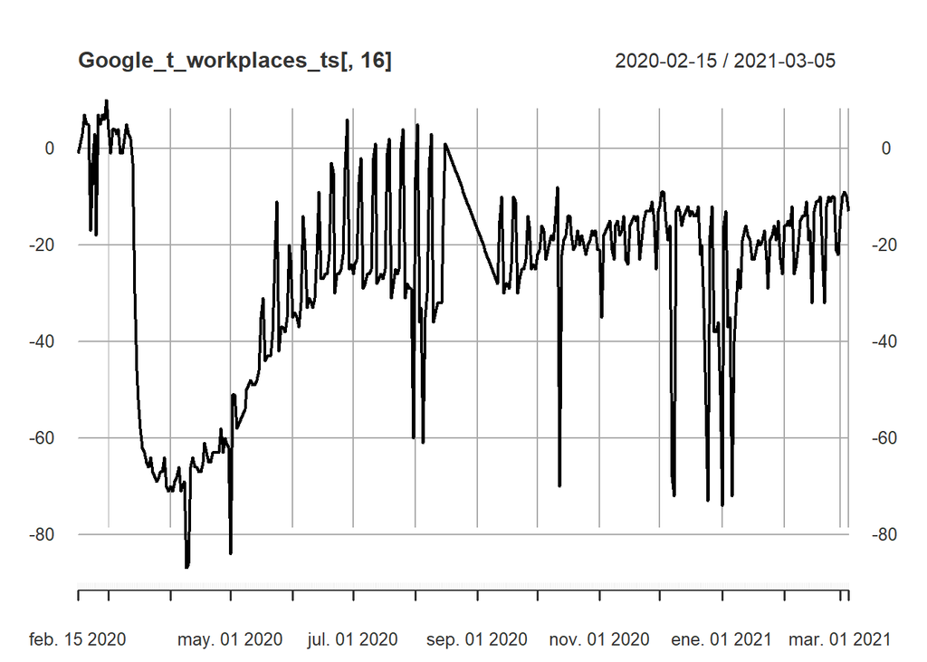

```r
# We select na_seadec for the dataset
Google_t_workplaces_ts <- na_seadec(Google_t_workplaces_ts)
plot(Google_t_workplaces_ts[,16])
```

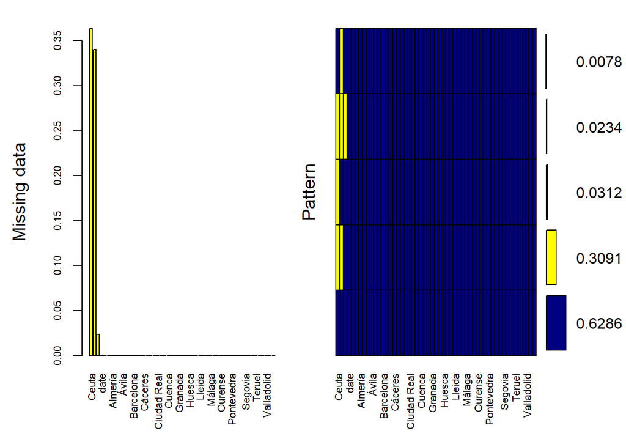

```
##
##  Variables sorted by number of missings:
##                Variable      Count
##                   Ceuta 0.36363636
##                 Melilla 0.34025974
##                   Soria 0.02337662
##                    date 0.00000000
##                Albacete 0.00000000
##        Alicante/Alacant 0.00000000
##                 Almería 0.00000000
##             Araba/Álava 0.00000000
##                Asturias 0.00000000
##                   Ávila 0.00000000
##                 Badajoz 0.00000000
##          Balears, Illes 0.00000000
##               Barcelona 0.00000000
##                 Bizkaia 0.00000000
##                  Burgos 0.00000000
##                 Cáceres 0.00000000
##                   Cádiz 0.00000000
##               Cantabria 0.00000000
##      Castellón/Castelló 0.00000000
##             Ciudad Real 0.00000000
##                 Córdoba 0.00000000
##               Coruña, A 0.00000000
##                  Cuenca 0.00000000
##                Gipuzkoa 0.00000000
##                  Girona 0.00000000
##                 Granada 0.00000000
##             Guadalajara 0.00000000
##                  Huelva 0.00000000
##                  Huesca 0.00000000
##                    Jaén 0.00000000
##                    León 0.00000000
##                  Lleida 0.00000000
##                    Lugo 0.00000000
##                  Madrid 0.00000000
##                  Málaga 0.00000000
##                  Murcia 0.00000000
##                 Navarra 0.00000000
##                 Ourense 0.00000000
##                Palencia 0.00000000
##             Palmas, Las 0.00000000
##              Pontevedra 0.00000000
##               Rioja, La 0.00000000
##               Salamanca 0.00000000
##  Santa Cruz de Tenerife 0.00000000
##                 Segovia 0.00000000
##                 Sevilla 0.00000000
##               Tarragona 0.00000000
##                  Teruel 0.00000000
##                  Toledo 0.00000000
##       Valencia/València 0.00000000
##              Valladolid 0.00000000
##                  Zamora 0.00000000
##                Zaragoza 0.00000000
```

```r
# We convert the time series object to a dataframe
Google_workplaces <- ts_df(Google_t_workplaces_ts)

names(Google_workplaces)[names(Google_workplaces) == "id"] <- "sub_region_2"
names(Google_workplaces)[names(Google_workplaces) == "time"] <- "Date"
names(Google_workplaces)[names(Google_workplaces) == "value"] <- "workplaces_percent_change_from_baseline"

###################################################################
# Transpose dataframe
Google_residential<-Google[c(2,4,10)]
Google_t_residential<-dcast(Google_residential, date~sub_region_2, fill=NA)

# Visualize missing values
aggr(Google_t_residential, col=c('navyblue','yellow'),
     numbers=TRUE, sortVars=TRUE,
     labels=names(Google_t_residential), cex.axis=.7,
     gap=3, ylab=c("Missing data","Pattern"))
```

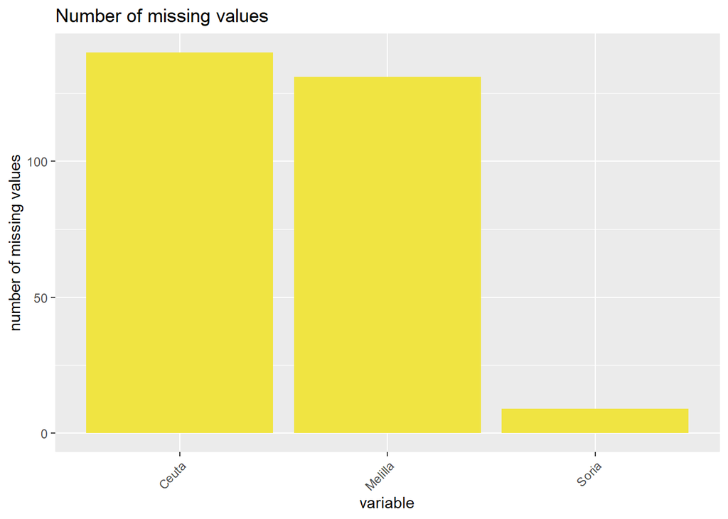

```r
Google_t_residential %>%
    gather(key = "key", value = "val") %>%
    mutate(is.missing = is.na(val)) %>%
    group_by(key, is.missing) %>%
    summarise(num.missing = n()) %>%
    filter(is.missing==T) %>%
    select(-is.missing) %>%
    arrange(desc(num.missing)) %>%
    ggplot() +
    geom_bar(aes(x=key, y=num.missing), stat = 'identity',fill="#F0E442") +
    labs(x='variable', y="number of missing values",
         title='Number of missing values') +
    theme(axis.text.x = element_text(angle = 45, hjust = 1))
```

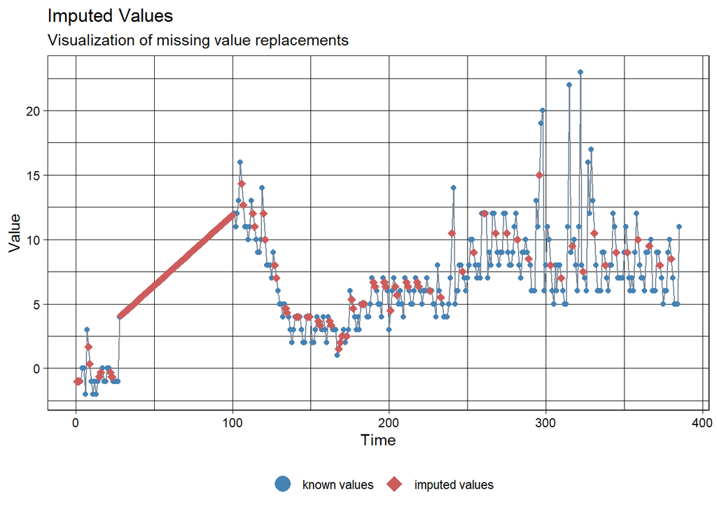

```r
# Convert dataframe to ts object
Google_t_residential_ts<-xts(Google_t_residential[-1],Google_t_residential$date)

# Impute the missing values with na_seadec (i.e Ceuta)
imp10 <- na_seadec(Google_t_residential_ts[,16])
ggplot_na_imputations(Google_t_residential_ts[,16], imp10)
```

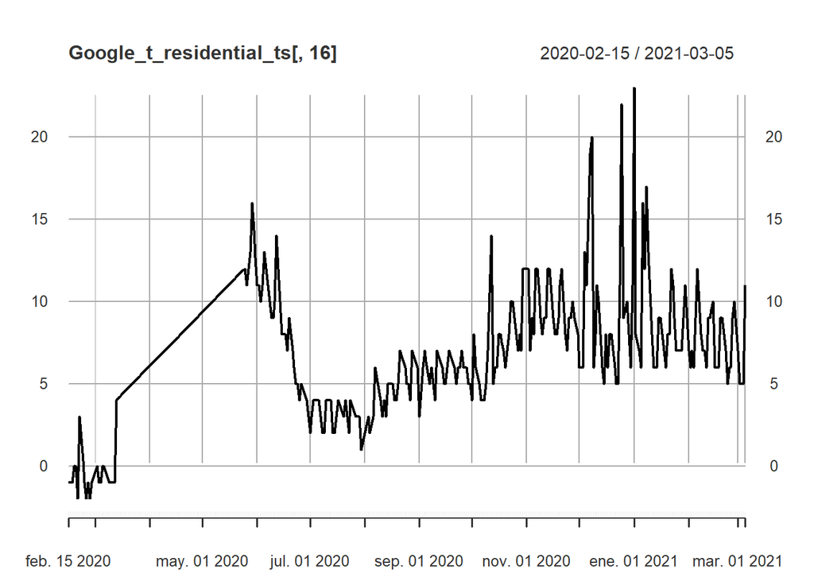

```r
# We select na_seadec for the dataset
Google_t_residential_ts <- na_seadec(Google_t_residential_ts)
plot(Google_t_residential_ts[,16])
```

```r
# We convert the time series object to a dataframe
Google_residential <- ts_df(Google_t_residential_ts)

names(Google_residential)[names(Google_residential) == "id"] <- "sub_region_2"
names(Google_residential)[names(Google_residential) == "time"] <- "Date"
names(Google_residential)[names(Google_residential) == "value"] <- "residential_percent_change_from_baseline"
```

Now we merge the previous dataframes into new one with the imputed vaules and we add the ISO code for the province.

```r
# New dataframe Google_b
Google_b <- merge(Google_retail, Google_grocery) %>%
              merge(Google_parks) %>%
              merge(Google_transit) %>%
              merge(Google_workplaces) %>%
              merge(Google_residential)

# We add the iso code for the province
Google_b$iso_code <- NA
Google_b$iso_code<-Google[match(Google_b$sub_region_2, Google$sub_region_2),3]
rm("Google")
Google<-Google_b
rm("Google_b")
head(Google,5)
```

```
##   sub_region_2       Date retail_and_recreation_percent_change_from_baseline
## 1     Albacete 2020-02-15                                                  3
## 2     Albacete 2020-02-16                                                  5
## 3     Albacete 2020-02-17                                                 -2
## 4     Albacete 2020-02-18                                                 -3
## 5     Albacete 2020-02-19                                                  0
##   grocery_and_pharmacy_percent_change_from_baseline
## 1                                                -5
## 2                                                 1
## 3                                                 3
## 4                                                -1
## 5                                                 1
##   parks_percent_change_from_baseline
## 1                                 35
## 2                                 40
```

[output cut: 21 more lines]

```r
table(Google$sub_region_2)
```

```
##
##               Albacete       Alicante/Alacant                Almería
##                    385                    385                    385
##            Araba/Álava               Asturias                  Ávila
##                    385                    385                    385
##                Badajoz         Balears, Illes              Barcelona
##                    385                    385                    385
##                Bizkaia                 Burgos                Cáceres
##                    385                    385                    385
##                  Cádiz              Cantabria     Castellón/Castelló
##                    385                    385                    385
##                  Ceuta            Ciudad Real                Córdoba
##                    385                    385                    385
##              Coruña, A                 Cuenca               Gipuzkoa
##                    385                    385                    385
##                 Girona                Granada            Guadalajara
##                    385                    385                    385
##                 Huelva                 Huesca                   Jaén
##                    385                    385                    385
##                   León                 Lleida                   Lugo
##                    385                    385                    385
##                 Madrid                 Málaga                Melilla
##                    385                    385                    385
##                 Murcia                Navarra                Ourense
##                    385                    385                    385
##               Palencia            Palmas, Las             Pontevedra
##                    385                    385                    385
##              Rioja, La              Salamanca Santa Cruz de Tenerife
##                    385                    385                    385
##                Segovia                Sevilla                  Soria
##                    385                    385                    385
##              Tarragona                 Teruel                 Toledo
##                    385                    385                    385
##      Valencia/València             Valladolid                 Zamora
##                    385                    385                    385
##               Zaragoza
##                    385
```

```r
table(Google$iso_code)
```

```
##
##   A  AB  AL  AV   B  BA  BI  BU   C  CA  CC  CE  CO  CR  CS  CU  GC  GI  GR  GU
## 385 385 385 385 385 385 385 385 385 385 385 385 385 385 385 385 385 385 385 385
##   H  HU   J   L  LE  LO  LU   M  MA  ML  MU  NA   O  OR   P  PM  PO   S  SA  SE
## 385 385 385 385 385 385 385 385 385 385 385 385 385 385 385 385 385 385 385 385
##  SG  SO  SS   T  TE  TF  TO   V  VA  VI   Z  ZA
## 385 385 385 385 385 385 385 385 385 385 385 385
```

We check missing values. We should obtain zero missing values.

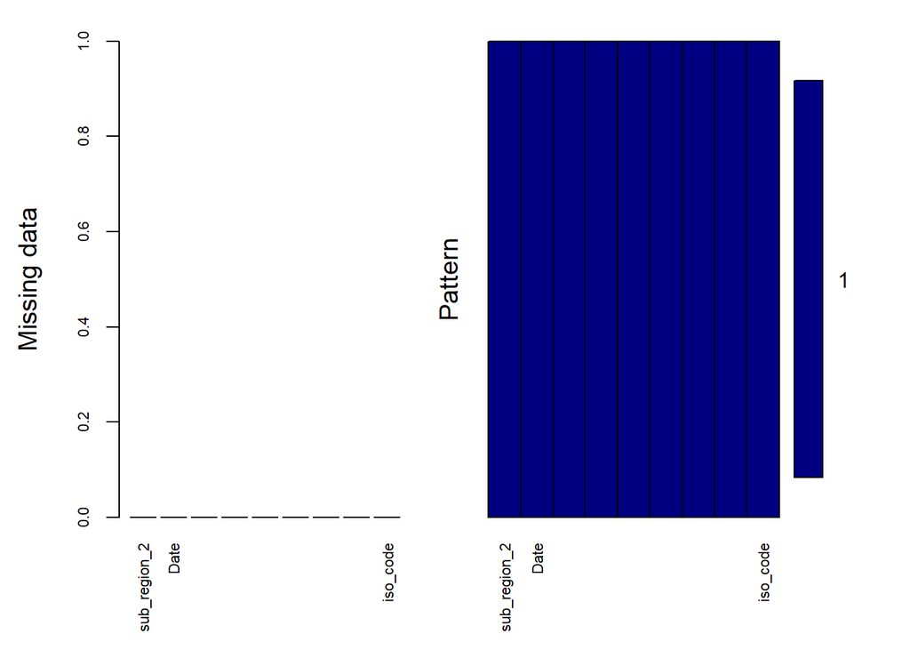

```
##
##  Variables sorted by number of missings:
##                                            Variable Count
##                                        sub_region_2     0
##                                                Date     0
##  retail_and_recreation_percent_change_from_baseline     0
##   grocery_and_pharmacy_percent_change_from_baseline     0
##                  parks_percent_change_from_baseline     0
##       transit_stations_percent_change_from_baseline     0
##             workplaces_percent_change_from_baseline     0
##            residential_percent_change_from_baseline     0
##                                            iso_code     0
```

```r
aggr(Google, col=c('navyblue','yellow'),
     numbers=TRUE, sortVars=TRUE,
     labels=names(Google), cex.axis=.7,
     gap=3, ylab=c("Missing data","Pattern"))
```

```r
Google %>%
    gather(key = "key", value = "val") %>%
    mutate(is.missing = is.na(val)) %>%
    group_by(key, is.missing) %>%
    summarise(num.missing = n()) %>%
    filter(is.missing==T) %>%
    select(-is.missing) %>%
    arrange(desc(num.missing)) %>%
    ggplot() +
    geom_bar(aes(x=key, y=num.missing), stat = 'identity',fill="#F0E442") +
    labs(x='variable', y="number of missing values",
         title='Number of missing values') +
    theme(axis.text.x = element_text(angle = 45, hjust = 1))
```

### 2.1.9 CNE review

The CSV files are provided per “imputed date” (fecha)":

- **cases_technic_province.csv** - Number of cases by diagnostic technique and province (of residence)
- **cases_hosp_uci_def_sexo_edad_provres.csv** - Number of hospitalizations, number of ICU admissions and number of deaths by sex, age and province of residence.

```r
head(str(CNE_tecnica, vec.len=3))
```

```
## 'data.frame':    23426 obs. of  8 variables:
##  $ provincia_iso               : chr  "A" "AB" "AL" ...
##  $ fecha                       : chr  "2020-01-01" "2020-01-01" "2020-01-01" ...
##  $ num_casos                   : int  0 0 0 0 0 0 0 0 ...
##  $ num_casos_prueba_pcr        : int  0 0 0 0 0 0 0 0 ...
##  $ num_casos_prueba_test_ac    : int  0 0 0 0 0 0 0 0 ...
##  $ num_casos_prueba_ag         : int  0 0 0 0 0 0 0 0 ...
##  $ num_casos_prueba_elisa      : int  0 0 0 0 0 0 0 0 ...
##  $ num_casos_prueba_desconocida: int  0 0 0 0 0 0 0 0 ...
```

```r
summary(CNE_tecnica)
```

```
##  provincia_iso         fecha             num_casos      num_casos_prueba_pcr
##  Length:23426       Length:23426       Min.   :   0.0   Min.   :   0.0
##  Class :character   Class :character   1st Qu.:   2.0   1st Qu.:   2.0
##  Mode  :character   Mode  :character   Median :  32.0   Median :  26.0
##                                        Mean   : 136.9   Mean   : 109.6
##                                        3rd Qu.: 120.0   3rd Qu.: 100.0
##                                        Max.   :6972.0   Max.   :6546.0
##  num_casos_prueba_test_ac num_casos_prueba_ag num_casos_prueba_elisa
##  Min.   : 0.0000          Min.   :   0.00     Min.   : 0.0000
##  1st Qu.: 0.0000          1st Qu.:   0.00     1st Qu.: 0.0000
##  Median : 0.0000          Median :   0.00     Median : 0.0000
##  Mean   : 0.2037          Mean   :  26.21     Mean   : 0.1602
##  3rd Qu.: 0.0000          3rd Qu.:   9.00     3rd Qu.: 0.0000
##  Max.   :32.0000          Max.   :3267.00     Max.   :71.0000
##  num_casos_prueba_desconocida
##  Min.   :  0.0000
##  1st Qu.:  0.0000
##  Median :  0.0000
##  Mean   :  0.7122
##  3rd Qu.:  0.0000
##  Max.   :505.0000
```

```r
table(CNE_tecnica$provincia_iso)
```

```
##
##   A  AB  AL  AV   B  BA  BI  BU   C  CA  CC  CE  CO  CR  CS  CU  GC  GI  GR  GU
## 442 442 442 442 442 442 442 442 442 442 442 442 442 442 442 442 442 442 442 442
##   H  HU   J   L  LE  LO  LU   M  MA  ML  MU  NC   O  OR   P  PM  PO   S  SA  SE
## 442 442 442 442 442 442 442 442 442 442 442 442 442 442 442 442 442 442 442 442
##  SG  SO  SS   T  TE  TF  TO   V  VA  VI   Z  ZA
## 442 442 442 442 442 442 442 442 442 442 442 442
```